# Deep Learning

Names: Jeyakumar Sriram (p2214618), Shawn Lim Jun Jie (p2239745)

Class: DAAA/FT/2A/01

Module Code: ST1504

## Objective:

Implement a Deep Q-Network (DQN) to control the Gym Pendulum environment, with the goal of training an agent to stabilize the pendulum in an upright position.

### Background:

Reinforcement learning has gained significant attention for solving complex control problems. The Gym Pendulum environment is good for practicing algorithms in continuous control tasks.

### The Gym Pendulum Environment:

The Gym Pendulum environment simulates a simple pendulum with continuous action space. The goal is to train an agent to apply torque to the pendulum, allowing it to stay upright. The state space consists of angular velocity and position, while the action space involves applying torque to the joint.

### Approach:

We will implement the DQN algorithm using PyTorch. The agent will learn to make decisions based on the current state of the pendulum, aiming to maximize cumulative rewards over time. The project will explore how well the DQN performs in mastering the control of the Gym Pendulum.

## Project Structure:

1. Imports
2. Exploring Pendulum Environment
3. Implementation of DQN with Theory
4. Model Improvement
   - Using best practices
   - Training Stabilization
   - Enchancing Action Space
   - Enhancing Optimization Strategy
   - Enhanching Model Architecture
5. Evaluation of Model
6. Conclusion

## References

- Mnih, V. et al. (2013) ‘Playing Atari with Deep Reinforcement Learning’, arXiv [cs.LG]. Available at: http://arxiv.org/abs/1312.5602.
- GeeksforGeeks. (2021). Bellman Equation. [online] Available at: https://www.geeksforgeeks.org/bellman-equation/.
- pytorch.org. (n.d.). Reinforcement Learning (DQN) Tutorial — PyTorch Tutorials 1.8.0 documentation. [online] Available at: https://pytorch.org/tutorials/intermediate/reinforcement_q_learning.html.
- livebook.manning.com. (n.d.). liveBook · Manning. [online] Available at: https://livebook.manning.com/concept/reinforcement-learning/target-network [Accessed 27 Jan. 2024].
- Wikipedia. (2020). Circular buffer. [online] Available at: https://en.wikipedia.org/wiki/Circular_buffer.
- baeldung (2020). Epsilon-Greedy Q-learning | Baeldung on Computer Science. [online] www.baeldung.com. Available at: https://www.baeldung.com/cs/epsilon-greedy-q-learning.
- Sewak, M. (06 2019) ‘Deep Q Network (DQN), Double DQN, and Dueling DQN: A Step Towards General Artificial Intelligence’, in, pp. 95–108. doi: 10.1007/978-981-13-8285-7_8.
- Wikipedia. (2023). Huber loss. [online] Available at: https://en.wikipedia.org/wiki/Huber_loss#:~:text=The%20Huber%20loss%20is%20the [Accessed 27 Jan. 2024].
- Mnih, V., Kavukcuoglu, K., Silver, D., et al. (2015). Human-level control through deep reinforcement learning. Nature, 518(7540), 529-533. DOI: [10.1038/nature14236](https://www.nature.com/articles/nature14236)
- van Hasselt, H., Guez, A., & Silver, D. (2016). Deep reinforcement learning with double Q-Learning. In Proceedings of the Thirtieth AAAI Conference on Artificial Intelligence (AAAI-16), 2094-2100. Retrieved from https://arxiv.org/abs/1509.06461
- Lin, L. J. (1992). Self-improving reactive agents based on reinforcement learning, planning and teaching. Machine Learning, 8(3-4), 293-321. DOI: 10.1007/BF00992699

## Imports

```python
import torch
import torch.nn as nn
import torch.optim as optim
import torch.nn.functional as F
from torchrl.modules import NoisyLinear

import gymnasium as gym
import math
import sys
import pygame
import numpy as np
import random
import matplotlib.pyplot as plt
import matplotlib.image as mpimg
from collections import namedtuple, deque
from itertools import count
```

```python
def showImage(path):
    img = mpimg.imread(path)
    plt.imshow(img)
    plt.axis('off')
    plt.show()

def plot_tuples(tuples_list, title):
    plt.figure()

    for array, name in tuples_list:
        plt.plot(array, label=name)

    plt.xlabel('Episodes')
    plt.ylabel('Score')
    plt.title('Comparison')
    plt.legend(title)
    plt.show()
```

## Exploring the Pendulum Environment

We will be trying to balance the pendulumn with it's center of gravity above the fixed point

[figure not shown]

```python
env = gym.make("Pendulum-v1",g=9.81)
device = torch.device("cuda" if torch.cuda.is_available() else "cpu")
```

### Observation Space

The environment gives us the following information about the pendulum that we can pass into the model.

[figure not shown]

```python
print(f"Number of Observations: {env.observation_space.shape}")
print(f"Minimum Value for Observations: {env.observation_space.low}")
print(f"Maximum Value for Observations: {env.observation_space.high}")
```

```
Number of Observations: (3,)
Minimum Value for Observations: [-1. -1. -8.]
Maximum Value for Observations: [1. 1. 8.]
```

### Action Space

Our model will generate just one variable T which ranges from -2.0 to 2.0. T is the torque measured in Nm to be applied on the pendulum. A positive T means we are turning it counter-clockwise and vice versa. So our DQN model should produce just one output in this range. Since a DQN doesn't work with Scalar Values, we will discretise this.

```python
print(f"Shape of Input: {env.action_space.shape}")
print(f"Minimum Value for Input: {env.action_space.low}")
print(f"Maximum Value for Input: {env.action_space.high}")
```

```
Shape of Input: (1,)
Minimum Value for Input: [-2.]
Maximum Value for Input: [2.]
```

## Implementation of DQN (with Theory)

> Deep Q-Network (DQN) is a reinforcement learning algorithm that combines deep neural networks with Q-learning, a classic reinforcement learning technique. Developed by researchers at DeepMind, DQN has proven to be effective in solving complex decision-making problems, particularly in domains with high-dimensional state spaces.

### Key Concepts

#### Q-Learning

Q-learning is a model-free reinforcement learning algorithm used to learn a policy for making decisions in an environment. The central idea is to approximate the optimal action-value function, denoted as Q(s, a), which represents the expected cumulative future rewards when taking action 'a' in state 's'.

#### Deep Neural Networks

Since Neural Networks are good function approximators, DQN utilizes them to approximate the action-value function. The neural network takes the state of the environment as input and outputs Q-values for each possible action.

#### Experience Replay

To stabilize training, DQN employs experience replay, a technique that stores and randomly samples past experiences from a replay buffer. This helps break the temporal correlations in the data, making the learning process more robust. By using a fixed size circular buffer, we can also ensure only the most recent n values are being learnt upon.

#### Loss Function

The loss function used in DQN is typically the mean squared error between the predicted Q-values and the target Q-values. This loss is minimized during training to improve the accuracy of the Q-value predictions.

### MLP

```python
# Our Policy Network is a Simple Multi Level Perceptron

class BaseMLP(nn.Module):
    def __init__(self, inp, out, lr):
        super(BaseMLP, self).__init__()

        self.layer1 = nn.Linear(inp, 32)
        self.layer2 = nn.Linear(32, 64)
        self.layer3 = nn.Linear(64, 32)
        self.layer4 = nn.Linear(32, out)

        self.lr = lr
        self.optimizer = optim.Adam(self.parameters(), lr=self.lr)

    def forward(self, x):
        x = self.layer1(x)
        x = F.relu(x)
        x = self.layer2(x)
        x = F.relu(x)
        x = self.layer3(x)
        x = F.relu(x)
        return self.layer4(x)
```

### Memory

When we use a DQN we need to have a way for the agent to remember past transitions. Transitions are, in simple english "what was there, what you did, what happened, is it good?". Technically it is a tuple with state, action, next_state, and reward.

Agent will not use the most recent memory only. Instead we will employ some random sampling to stabilise the training so the model doesn't get caught up with short term patterns.

A good data structure for this will be a circular buffer. This is a queue data struct which follows a FIFO principle. One important thing to note here is that once the buffer is full, subsequent writes will overwrite exisiting data starting from the oldest. This helps to remove extremely old data.

[figure not shown]

When we take past memory to train the model, we will also take it in batches. Of course, the samples will be picked randomly.

```python
class Memory(object):

    def __init__(self, maxlen):
        self.buffer = deque([], maxlen=maxlen)
    def push(self, transition):
        self.buffer.append(transition)

    def sample(self, batch_size):
        mini_batch = random.sample(self.buffer, batch_size)
        states, actions, rewards, next_states = [], [], [], []
        # perform some manipulation to ensure dtypes match
        for transition in mini_batch:
            s, a, r, ns = transition
            states.append(s) # s is a tensor not a regular element
            actions.append([a])
            rewards.append([r])
            next_states.append(ns)

        states = torch.stack(states)
        actions = torch.tensor(actions, dtype=torch.float)
        rewards = torch.tensor(rewards, dtype=torch.float)
        next_states = torch.stack(next_states)
        return states, actions, rewards, next_states

    def __len__(self):
        return len(self.buffer)
```

### DQN Agent

We have a build a very simple DQN with no additional improvements here.

#### 1. Initialization

- **Memory Buffer:** A replay memory buffer (`Memory`) stores past experiences for experience replay during training.
- **Neural Network:** The Q-function approximator (policy net) takes the state as input and outputs Q-values for each action.

#### 2. Action Selection

- The `action` method selects actions based on Q-values predicted by the policy net. The selected action is scaled to match the desired action space.

#### 3. Training Optimization

- The `optimize` method updates Q-function parameters using experiences sampled from the replay memory.
  - **Mini-Batch Sampling:** A mini-batch of experiences (state, action, reward, next_state) is sampled from the replay memory.
  - **Target Calculation:** Target Q-values (`yi`) are calculated using the Bellman equation, considering immediate reward and the maximum Q-value for the next state.
  - **Loss Calculation:** The mean squared error loss is computed between predicted and target Q-values.

#### 4. Hyperparameters

```python
class DQNAgent:
    def __init__(self):
        self.steps = 0
        self.memory = Memory(10000)

        self.batch_size = 256
        self.adamlr = 0.001
        self.gamma = 0.98

        # policy net, aka, Q function
        self.policy_net = BaseMLP(3, 9,self.adamlr)

    def action(self,state):

        with torch.no_grad():
            choice = float(torch.argmax(self.policy_net(state)).numpy())
            action = (choice-4)/2

        return choice, action

    def optimize(self):
        if len(self.memory) < self.batch_size:
            return

        batch = self.memory.sample(self.batch_size)
        state, action, reward, next_state = batch
        action = action.type(torch.int64)

        # target
        with torch.no_grad():   # parameters from previous iteration are held fixed
            yi = reward + self.gamma * self.policy_net(next_state).max(1)[0].unsqueeze(1)

        # Q(phi_i, a_i, theta)
        current_state_action = self.policy_net(state).gather(1,action)

        # Back_propagation
        loss = (yi - current_state_action) ** 2
        self.policy_net.optimizer.zero_grad()
        loss.mean().backward()
        self.policy_net.optimizer.step()
```

### Training Setup

We train our model over a set number of episodes, where each episode represents a single game with a maximum of 200 steps. State updates occur after each step, and we check if the activity is completed.

To ensure an adequate amount of data for learning, we initiate backpropagation only after completing 1000 steps. This step threshold ensures a substantial dataset to sample from during the training process.

#### Gym Environment Update

It's worth noting that in the updated Gym library, the environment now returns 5 values instead of 4. The 'done' signal has been divided into 'terminated' and 'truncated' to specify how the episode concluded. Currently, our model doesn't utilize this additional information.

#### Logging

We take the cumulative sum of rewards as the key metric for this model. At the same time we also log the number of steps the model has sustained as an additional indicator of performacne. After each training we also display a graph of the score change over the training period.

```python
def train_model(DQNAgentX, episodes):
    agent = DQNAgentX()
    env = gym.make('Pendulum-v1')
    score_list = []
    for episode in range(episodes):
        print(f"Episode: {episode}",end="")
        state, _ = env.reset()
        state = torch.tensor(state)
        done = False
        score = 0
        while not done:
            choice, action = agent.action(state)

            next_state, reward, terminated, truncated, _ = env.step([action])

            score+=reward
            done = terminated or truncated

            if terminated:
                next_state = None
            else:
                next_state = torch.tensor(next_state,dtype=torch.float32)

            agent.memory.push((state, choice, reward, next_state ))
            state = next_state

            if len(agent.memory) > 1000:
                agent.optimize()

        print(f", Score: {score}")
        score_list.append(score)

    env.close()

    plt.plot(score_list)
    plt.show()

    return agent, score_list
```

```
Episode: 0, Score: -1579.4195666572894
Episode: 1, Score: -1603.513772210122
Episode: 2, Score: -1485.4663338372372
Episode: 3, Score: -1614.6608772658776
Episode: 4, Score: -1665.7581725785196
Episode: 5, Score: -1300.5187398415367
Episode: 6, Score: -1439.800386187149
Episode: 7, Score: -1268.57657133863
Episode: 8, Score: -1503.0542223798968
Episode: 9, Score: -1563.3456587971223
Episode: 10, Score: -1236.465435257366
Episode: 11, Score: -1188.8184146230865
Episode: 12, Score: -1082.542962597973
Episode: 13, Score: -1327.4170534703405
Episode: 14, Score: -1012.4901028463876
Episode: 15, Score: -1243.162094714658
Episode: 16, Score: -970.7389728081843
Episode: 17, Score: -1469.4509677322205
Episode: 18, Score: -1000.1142904508289
Episode: 19, Score: -1243.6948686697665
Episode: 20, Score: -1242.3545577148557
Episode: 21, Score: -1382.2397216814861
Episode: 22, Score: -1217.305919466091
Episode: 23, Score: -1244.6182254348903
Episode: 24, Score: -1168.8360587798604
Episode: 25, Score: -1271.4406996821242
Episode: 26, Score: -904.2856811820027
Episode: 27, Score: -1282.03569891004
Episode: 28, Score: -976.9907649673164
Episode: 29, Score: -978.7395613172323
Episode: 30, Score: -1015.8981040452671
Episode: 31, Score: -1046.2635625224023
Episode: 32, Score: -1055.8020271335886
Episode: 33, Score: -1157.074149501029
Episode: 34, Score: -869.8697303608835
Episode: 35, Score: -1088.4826199917877
Episode: 36, Score: -1037.9806602242068
Episode: 37, Score: -1022.7539167571592
Episode: 38, Score: -1037.9211091277934
Episode: 39, Score: -1023.0495689382597
```

[output cut: 345 more lines]

```
Episode: 385, Score: -126.19608787316567
Episode: 386, Score: -124.01609539082379
Episode: 387, Score: -124.28682167595251
Episode: 388, Score: -117.27734736817624
Episode: 389, Score: -251.00034865211063
Episode: 390, Score: -561.2801793365759
Episode: 391, Score: -0.9262286198002831
Episode: 392, Score: -125.9348755508311
Episode: 393, Score: -248.4066311894941
Episode: 394, Score: -2.7696993059906383
Episode: 395, Score: -251.12637792581035
Episode: 396, Score: -116.21277884459721
Episode: 397, Score: -124.8328132785567
Episode: 398, Score: -349.43688935071543
Episode: 399, Score: -0.9955939609326678
```

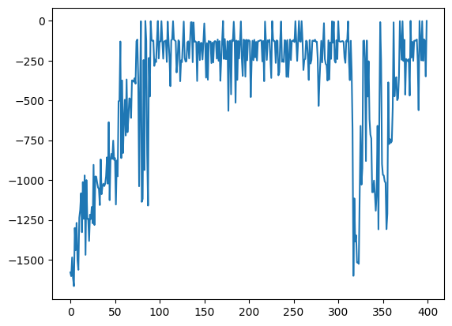

```python
baseAgent, base_score = train_model(DQNAgent,400)
```

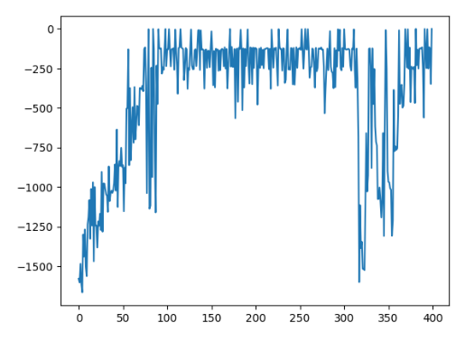

```python
torch.save(baseAgent.policy_net.state_dict(), "./rl_models/base.pt")
showImage("./Imgs_RL/simple_dqn.png")
```

Observations:

- Model takes around 100 episodes to perform well
- Model is not very stable as it's score oscillates heavily throughly the training process even after 300 episodes
- Model is not consistent as you can see drastic decreases in score frequently. This is due to a inherent problem with vanilla DQNs called "Catastrophic Forgetting". This is because when a model sees new unseen information and tries to optimise for it, it might forget previouslyt learned information.

To define the performance of the model in a single metric, I will also compute the 100 epoch average.

```python
def evaluate_model(agent, episodes):

    # Initialize Pendulum environment for visualization
    env_visualize = gym.make('Pendulum-v1')
    scores = []
    # Visualization loop
    for episode in range(episodes):
        print(f"Evaluating Episode: {episode+1}", end="")

        # Reset the environment for a new episode
        state, info = env_visualize.reset()
        state = torch.tensor(state)

        done = False
        score = 0

        # Episode simulation loop
        while not done:
            # Render the environment (visualize the Pendulum)

            # Choose an action using the trained DQNAgent
            choice, action = agent.action(state)

            # Take a step in the environment
            next_state, reward, terminated, truncated, _ = env_visualize.step([action])

            # Update the total score
            score += reward
            done = terminated or truncated

            # If the episode is terminated, set next_state to None; otherwise, convert it to a tensor
            next_state = None if terminated else torch.tensor(next_state, dtype=torch.float32)

            state = next_state

        scores.append(score)
        # Print episode score
        print(f", Score: {score}")
    print(f"Final Score: {np.mean(scores)}")
    # Close the visualization environment after visualizing
    env_visualize.close()
```

```python
evaluate_model(baseAgent,100)
```

```
Evaluating Episode: 1, Score: -3.5438824587240347
Evaluating Episode: 2, Score: -123.83347466187878
Evaluating Episode: 3, Score: -121.02931821935753
Evaluating Episode: 4, Score: -122.60711051593276
Evaluating Episode: 5, Score: -123.87477125265588
Evaluating Episode: 6, Score: -121.39073792407005
Evaluating Episode: 7, Score: -232.45548308838042
Evaluating Episode: 8, Score: -118.27427991300173
Evaluating Episode: 9, Score: -1614.5584798730147
Evaluating Episode: 10, Score: -125.9734429461688
Evaluating Episode: 11, Score: -119.33248629284242
Evaluating Episode: 12, Score: -225.7548796433445
Evaluating Episode: 13, Score: -125.66170010634822
Evaluating Episode: 14, Score: -232.49062314725506
Evaluating Episode: 15, Score: -117.64351501030193
Evaluating Episode: 16, Score: -119.42947160046955
Evaluating Episode: 17, Score: -127.0705489585355
Evaluating Episode: 18, Score: -123.747247490065
Evaluating Episode: 19, Score: -122.49371005129927
Evaluating Episode: 20, Score: -1.1974502301650078
Evaluating Episode: 21, Score: -1611.3930311678887
Evaluating Episode: 22, Score: -125.31308965094067
Evaluating Episode: 23, Score: -122.53929855810125
Evaluating Episode: 24, Score: -117.48910994803211
Evaluating Episode: 25, Score: -125.33206680911579
Evaluating Episode: 26, Score: -124.3829455610465
Evaluating Episode: 27, Score: -0.5775502017606964
Evaluating Episode: 28, Score: -124.97248001977302
Evaluating Episode: 29, Score: -119.05037607630415
Evaluating Episode: 30, Score: -1.1989125172779056
Evaluating Episode: 31, Score: -126.6371779945372
Evaluating Episode: 32, Score: -0.7745213056306275
Evaluating Episode: 33, Score: -126.97031255337832
Evaluating Episode: 34, Score: -361.67444401198424
Evaluating Episode: 35, Score: -242.8750265267138
Evaluating Episode: 36, Score: -116.60926173778357
Evaluating Episode: 37, Score: -240.90136419628362
Evaluating Episode: 38, Score: -262.9605893809454
Evaluating Episode: 39, Score: -126.18607795400476
Evaluating Episode: 40, Score: -128.59182730819347
```

[output cut: 46 more lines]

```
Evaluating Episode: 87, Score: -226.874429163204
Evaluating Episode: 88, Score: -1.0571426397926864
Evaluating Episode: 89, Score: -248.93138647395145
Evaluating Episode: 90, Score: -0.6003637728633788
Evaluating Episode: 91, Score: -122.664394400944
Evaluating Episode: 92, Score: -124.77279981923446
Evaluating Episode: 93, Score: -1620.3909757619272
Evaluating Episode: 94, Score: -126.58146291641322
Evaluating Episode: 95, Score: -245.02708006692893
Evaluating Episode: 96, Score: -126.32558832297109
Evaluating Episode: 97, Score: -228.22916104586628
Evaluating Episode: 98, Score: -116.36103220393856
Evaluating Episode: 99, Score: -121.16191807893254
Evaluating Episode: 100, Score: -127.09296454156873
Final Score: -215.03666901686105
```

Score of -215 is not a bad score but I believe we can do better. I actually found a leaderboard from openai's repo. And the best score overall is -106. So our score of -215 is not bad at all.

[figure not shown]

### Visualising Model Performance

While metrics are useful in viewing the performance of a model, sometimes seeing how it balances a pendulum can give insights into the perofrmance of a model

```python
def visualize_model(agent, episodes):

    # Initialize Pendulum environment for visualization
    env_visualize = gym.make('Pendulum-v1', render_mode='human')

    # Visualization loop
    for episode in range(episodes):
        print(f"Visualizing Episode: {episode+1}", end="")

        # Reset the environment for a new episode
        state, info = env_visualize.reset()
        state = torch.tensor(state)

        done = False
        score = 0

        # Episode simulation loop
        while not done:
            # Render the environment (visualize the Pendulum)
            env_visualize.render()

            # Choose an action using the trained DQNAgent
            choice, action = agent.action(state)

            # Take a step in the environment
            next_state, reward, terminated, truncated, _ = env_visualize.step([action])

            # Update the total score
            score += reward
            done = terminated or truncated

            # If the episode is terminated, set next_state to None; otherwise, convert it to a tensor
            next_state = None if terminated else torch.tensor(next_state, dtype=torch.float32)

            state = next_state

            for event in pygame.event.get():
                if event.type == pygame.QUIT:
                    pygame.quit()
                    sys.exit()

        # Print episode score
        print(f", Score: {score}")

    # Close the visualization environment after visualizing
    env_visualize.close()
```

```python
visualize_model(baseAgent,3)
```

```
Visualizing Episode: 1, Score: -221.7184656001412
Visualizing Episode: 2, Score: -117.59488499322866
Visualizing Episode: 3, Score: -126.89623739450441
```

Observations:

- Upon visual inspection, the model demonstrates the ability to moderately balance the pendulum.
- This suggests that the model has effectively learned to play the game well.

Issue:

- While the model successfully balances the pendulum on top, it is observed that it applies substantial force on both sides to maintain balance.
- The issue arises from the limitations of the action discrete array.
- The current array lacks fine-grained options near zero, preventing the model from exerting small amounts of force to delicately control the pendulum.

Solutions:

- Increase Action Array Size:
  - One potential solution is to increase the size of the action array, providing more options for the model to exert varying levels of force.
- Quadratic Spread:
  - Another approach is to make the spread of the action array quadratic, allowing for more nuanced control near zero.

By addressing the limitations of the action discrete array, the goal is to enable the model to exert precise control over the pendulum, leading to improved performance and a more realistic balance.

## Model Improvement

### Using Best Practices

Before moving on to more complicated improvements, I would like to get the basics right. I will implement this change to my model.

**Leaky ReLU Activation:**

- **Change:** Replace traditional ReLU activation functions with Leaky ReLU.
- **Reasoning:** Leaky ReLU allows a small, non-zero gradient for negative inputs, addressing the "dying ReLU" problem and providing a more robust learning signal during training.

This will involve changing the BaseMLP and DQNAgent Classes.

```python
class MLP(nn.Module):
    def __init__(self, inp, out, lr):
        super(MLP, self).__init__()

        self.layer1 = nn.Linear(inp, 32)
        self.layer2 = nn.Linear(32, 64)
        self.layer3 = nn.Linear(64, 32)
        self.layer4 = nn.Linear(32, out)

        self.lr = lr
        self.optimizer = optim.Adam(self.parameters(), lr=self.lr)

    def forward(self, x):
        x = self.layer1(x)
        x = F.leaky_relu(x)
        x = self.layer2(x)
        x = F.leaky_relu(x)
        x = self.layer3(x)
        x = F.leaky_relu(x)
        return self.layer4(x)
```

```python
class DQNAgentImp:
    def __init__(self):
        self.steps = 0
        self.memory = Memory(10000)

        self.batch_size = 256
        self.adamlr = 0.001
        self.gamma = 0.98

        self.policy_net = MLP(3, 9,self.adamlr)

    def action(self,state):

        with torch.no_grad():
            choice = float(torch.argmax(self.policy_net(state)).numpy())
            action = (choice-4)/2

        return choice, action

    def optimize(self):
        if len(self.memory) < self.batch_size:
            return

        batch = self.memory.sample(self.batch_size)
        state, action, reward, next_state = batch
        action = action.type(torch.int64)

        # target
        with torch.no_grad():   # parameters from previous iteration are held fixed
            yi = reward + self.gamma * self.policy_net(next_state).max(1)[0].unsqueeze(1)

        # Q(phi_i, a_i, theta)
        current_state_action = self.policy_net(state).gather(1,action)

        # Back_propagation
        loss = (yi - current_state_action) ** 2
        self.policy_net.optimizer.zero_grad()
        loss.mean().backward()
        self.policy_net.optimizer.step()
```

```
Episode: 0, Score: -1553.2304905499973
Episode: 1, Score: -1345.786433827973
Episode: 2, Score: -1610.8623846006146
Episode: 3, Score: -1467.304045481317
Episode: 4, Score: -1508.4749737380137
Episode: 5, Score: -1079.4317592400578
Episode: 6, Score: -984.5120400278432
Episode: 7, Score: -1165.4430290780197
Episode: 8, Score: -1372.9529315342947
Episode: 9, Score: -1384.5929356151892
Episode: 10, Score: -1094.9811055682258
Episode: 11, Score: -1080.0286206677508
Episode: 12, Score: -1336.1506245617513
Episode: 13, Score: -1624.1738042134452
Episode: 14, Score: -1493.1655109910896
Episode: 15, Score: -1561.0438099877813
Episode: 16, Score: -1539.0310030244348
Episode: 17, Score: -1649.566996486605
Episode: 18, Score: -1311.7490700303113
Episode: 19, Score: -1289.4546604021882
Episode: 20, Score: -1290.645230202009
Episode: 21, Score: -1117.4564724205356
Episode: 22, Score: -899.2375290251363
Episode: 23, Score: -1172.2328140792215
Episode: 24, Score: -980.8046883054704
Episode: 25, Score: -1012.7012546302924
Episode: 26, Score: -995.2309724167021
Episode: 27, Score: -846.3600039584428
Episode: 28, Score: -966.2293377483484
Episode: 29, Score: -963.132129219019
Episode: 30, Score: -869.8442177760018
Episode: 31, Score: -738.7136821489945
Episode: 32, Score: -947.243242206997
Episode: 33, Score: -864.2247598047114
Episode: 34, Score: -864.541988421007
Episode: 35, Score: -976.6988318081335
Episode: 36, Score: -784.6994156477843
Episode: 37, Score: -987.7847537664051
Episode: 38, Score: -875.6270606557247
Episode: 39, Score: -737.4653444407444
```

[output cut: 245 more lines]

```
Episode: 285, Score: -593.8231608618735
Episode: 286, Score: -869.230730692613
Episode: 287, Score: -528.4106059020986
Episode: 288, Score: -626.0889333877358
Episode: 289, Score: -1002.0711513568383
Episode: 290, Score: -748.6904062592226
Episode: 291, Score: -1087.4368130677399
Episode: 292, Score: -986.7777170740212
Episode: 293, Score: -747.7837286423969
Episode: 294, Score: -1009.2093106956748
Episode: 295, Score: -1035.7722432406185
Episode: 296, Score: -944.150898687658
Episode: 297, Score: -904.7484737806642
Episode: 298, Score: -922.7073643518416
Episode: 299, Score: -923.652839445085
```

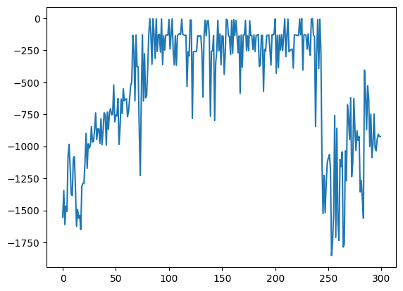

```
Episode: 0, Score: -1172.9617595045681
Episode: 1, Score: -1151.9078940643892
Episode: 2, Score: -1202.9726589044662
Episode: 3, Score: -1375.338247208075
Episode: 4, Score: -1193.1050051442926
Episode: 5, Score: -1379.361256233199
Episode: 6, Score: -1314.922571886764
Episode: 7, Score: -1183.9721651189222
Episode: 8, Score: -1444.0077554311779
Episode: 9, Score: -1226.3325619801828
Episode: 10, Score: -1196.1173116245566
Episode: 11, Score: -1365.2837073861992
Episode: 12, Score: -1079.7076248015692
Episode: 13, Score: -1215.7502069795764
Episode: 14, Score: -1270.234252758934
Episode: 15, Score: -1217.7533896741063
Episode: 16, Score: -1187.7903343172832
Episode: 17, Score: -1350.6759232861016
Episode: 18, Score: -887.7760896008308
Episode: 19, Score: -1150.3970110838623
Episode: 20, Score: -1003.7077000242513
Episode: 21, Score: -1323.6849422253572
Episode: 22, Score: -1228.784805143345
Episode: 23, Score: -1459.4790462149845
Episode: 24, Score: -1195.7312187902487
Episode: 25, Score: -1405.1736730947607
Episode: 26, Score: -1158.7063266293023
Episode: 27, Score: -1029.8364183406454
Episode: 28, Score: -1016.7066193394087
Episode: 29, Score: -1117.941586346379
Episode: 30, Score: -966.7758200350683
Episode: 31, Score: -1162.4902925941549
Episode: 32, Score: -969.7971414273904
Episode: 33, Score: -1106.5286577233746
Episode: 34, Score: -1129.9048323259979
Episode: 35, Score: -1008.5068417807832
Episode: 36, Score: -875.8420303242574
Episode: 37, Score: -919.5224696004113
Episode: 38, Score: -1002.3251079179493
Episode: 39, Score: -765.8086202075306
```

[output cut: 245 more lines]

```
Episode: 285, Score: -127.44845553614408
Episode: 286, Score: -125.82824702221039
Episode: 287, Score: -11.383789722760307
Episode: 288, Score: -132.7717567474053
Episode: 289, Score: -134.77534509411035
Episode: 290, Score: -123.5835239301171
Episode: 291, Score: -4.722876152646389
Episode: 292, Score: -127.66064531224131
Episode: 293, Score: -251.88893165444702
Episode: 294, Score: -6.215592142435282
Episode: 295, Score: -6.990223785859828
Episode: 296, Score: -116.32498347353373
Episode: 297, Score: -231.30028462618293
Episode: 298, Score: -244.71382540762627
Episode: 299, Score: -4.412290325294387
```

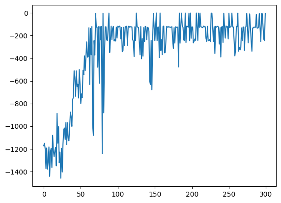

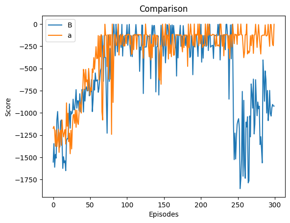

```python
baseAgent, base_score = train_model(DQNAgent,300)
improvedAgent, improved_score = train_model(DQNAgentImp,300)
plot_tuples([(base_score,"base"),(improved_score,"best")],"Base vs Best Practices")
```

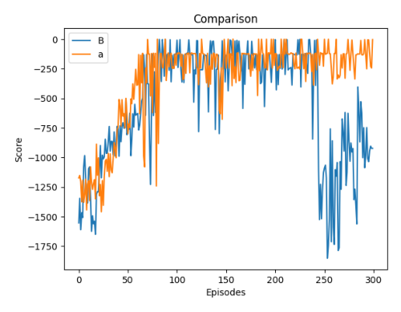

```python
torch.save(improvedAgent.policy_net.state_dict(), "./rl_models/improved.pt")
showImage("./Imgs_RL/added_leaky_relu.png")
```

```python
evaluate_model(baseAgent,100)
```

```
Evaluating Episode: 1, Score: -1201.1995185104172
Evaluating Episode: 2, Score: -1186.1421552471024
Evaluating Episode: 3, Score: -1191.1385639932867
Evaluating Episode: 4, Score: -1201.9092745921062
Evaluating Episode: 5, Score: -1190.8787614738426
Evaluating Episode: 6, Score: -804.5394741620818
Evaluating Episode: 7, Score: -1221.1918615899008
Evaluating Episode: 8, Score: -1188.9339394180201
Evaluating Episode: 9, Score: -1190.5634314348347
Evaluating Episode: 10, Score: -1195.2881979093152
Evaluating Episode: 11, Score: -1183.562516205666
Evaluating Episode: 12, Score: -1187.6975535956753
Evaluating Episode: 13, Score: -1184.2673682234838
Evaluating Episode: 14, Score: -1211.3206536406162
Evaluating Episode: 15, Score: -1220.0047354615392
Evaluating Episode: 16, Score: -1182.1586356337962
Evaluating Episode: 17, Score: -1171.9233514512623
Evaluating Episode: 18, Score: -1198.6910967963877
Evaluating Episode: 19, Score: -1044.6449134294276
Evaluating Episode: 20, Score: -1186.2231497246648
Evaluating Episode: 21, Score: -1165.350319157556
Evaluating Episode: 22, Score: -1214.8660451964302
Evaluating Episode: 23, Score: -1265.5170396703302
Evaluating Episode: 24, Score: -1192.5854123831673
Evaluating Episode: 25, Score: -1202.773634212631
Evaluating Episode: 26, Score: -1232.4998630479872
Evaluating Episode: 27, Score: -1196.0146084746361
Evaluating Episode: 28, Score: -1072.8646054749538
Evaluating Episode: 29, Score: -1189.4727585027242
Evaluating Episode: 30, Score: -1185.0048391622927
Evaluating Episode: 31, Score: -1071.2540750658463
Evaluating Episode: 32, Score: -1188.0772297880562
Evaluating Episode: 33, Score: -1203.1911218866294
Evaluating Episode: 34, Score: -1199.2363164156495
Evaluating Episode: 35, Score: -1160.520865153369
Evaluating Episode: 36, Score: -1198.7764980822778
Evaluating Episode: 37, Score: -1198.9828514956753
Evaluating Episode: 38, Score: -1202.2606634678023
Evaluating Episode: 39, Score: -1225.7474905350525
Evaluating Episode: 40, Score: -1264.9272437473496
```

[output cut: 46 more lines]

```
Evaluating Episode: 87, Score: -1177.3935645381155
Evaluating Episode: 88, Score: -1200.4878167618326
Evaluating Episode: 89, Score: -1142.6193236927968
Evaluating Episode: 90, Score: -1203.138519873201
Evaluating Episode: 91, Score: -1181.5622083238409
Evaluating Episode: 92, Score: -1054.0099947898414
Evaluating Episode: 93, Score: -1191.9106932326517
Evaluating Episode: 94, Score: -1194.856840651913
Evaluating Episode: 95, Score: -1236.1934098675747
Evaluating Episode: 96, Score: -1199.6618537541433
Evaluating Episode: 97, Score: -1200.8151886413714
Evaluating Episode: 98, Score: -1208.7774377668663
Evaluating Episode: 99, Score: -1148.2704851705016
Evaluating Episode: 100, Score: -1196.3470533154957
Final Score: -1179.553622567776
```

```python
evaluate_model(improvedAgent,100)
```

```
Evaluating Episode: 1, Score: -125.19273663064577
Evaluating Episode: 2, Score: -228.88074451907121
Evaluating Episode: 3, Score: -1.5658796387360794
Evaluating Episode: 4, Score: -120.38888903218249
Evaluating Episode: 5, Score: -115.08704786142602
Evaluating Episode: 6, Score: -121.00840725538347
Evaluating Episode: 7, Score: -125.52391964159162
Evaluating Episode: 8, Score: -1.7934736986394302
Evaluating Episode: 9, Score: -128.36517999596995
Evaluating Episode: 10, Score: -247.92646476893867
Evaluating Episode: 11, Score: -125.27701220511095
Evaluating Episode: 12, Score: -447.5055630717795
Evaluating Episode: 13, Score: -232.62556224675754
Evaluating Episode: 14, Score: -3.126555459554056
Evaluating Episode: 15, Score: -238.71413995382366
Evaluating Episode: 16, Score: -324.03139511078706
Evaluating Episode: 17, Score: -125.68939970323304
Evaluating Episode: 18, Score: -1.702359255051591
Evaluating Episode: 19, Score: -122.30174980043112
Evaluating Episode: 20, Score: -376.4314298540044
Evaluating Episode: 21, Score: -125.4336267291072
Evaluating Episode: 22, Score: -1.313470737973587
Evaluating Episode: 23, Score: -128.48250026775116
Evaluating Episode: 24, Score: -230.6797813335825
Evaluating Episode: 25, Score: -126.40629431592993
Evaluating Episode: 26, Score: -2.271593743046745
Evaluating Episode: 27, Score: -121.08032906430928
Evaluating Episode: 28, Score: -240.44475012162604
Evaluating Episode: 29, Score: -122.05802882153588
Evaluating Episode: 30, Score: -126.13918130952189
Evaluating Episode: 31, Score: -232.97709770419266
Evaluating Episode: 32, Score: -337.19343392958876
Evaluating Episode: 33, Score: -241.37915739730627
Evaluating Episode: 34, Score: -124.83117978628538
Evaluating Episode: 35, Score: -123.5980864602523
Evaluating Episode: 36, Score: -242.48297189678263
Evaluating Episode: 37, Score: -121.03470155504932
Evaluating Episode: 38, Score: -251.99264843326455
Evaluating Episode: 39, Score: -242.6564923243504
Evaluating Episode: 40, Score: -1.4744452448771213
```

[output cut: 46 more lines]

```
Evaluating Episode: 87, Score: -225.82531118290362
Evaluating Episode: 88, Score: -128.28554550905457
Evaluating Episode: 89, Score: -117.62580937835203
Evaluating Episode: 90, Score: -125.9508652249148
Evaluating Episode: 91, Score: -239.58636849856921
Evaluating Episode: 92, Score: -118.03860242300429
Evaluating Episode: 93, Score: -238.97263216603804
Evaluating Episode: 94, Score: -115.3281884804444
Evaluating Episode: 95, Score: -1.5305842457641325
Evaluating Episode: 96, Score: -246.29451172421435
Evaluating Episode: 97, Score: -126.82917885684667
Evaluating Episode: 98, Score: -123.11075482791087
Evaluating Episode: 99, Score: -127.20183332803614
Evaluating Episode: 100, Score: -115.36759250036938
Final Score: -157.55953378955527
```

Based on the graph, I find the Leaky_Relu to have improved the model slightly. At the beginning, I feel that the mode improved faster. but nevertheless its a slight improvement.

### Training Stabilization

#### Greedy Epsilon

During training, incorporating the Greedy Epsilon strategy enhances the stability of your Deep Q-Network (DQN) by managing the trade-off between exploration and exploitation. I hope this will stabilise the intial part of the training process.

- **What:** The Greedy Epsilon strategy allows the agent to choose between exploiting the best-known action with high probability and exploring new actions with a controlled probability.
- **Why:** By dynamically adjusting the exploration rate, the model avoids premature convergence to suboptimal policies. This ensures a more balanced exploration of the state-action space, preventing the DQN from getting stuck in local minima and facilitating a more stable learning process.

[figure not shown]

#### Gradient Clipping

By controlling how much the model can change, I hope to mitigate "catastrophic forgetting" among the DQN.

- **What:** Gradient clipping involves limiting the magnitude of gradients during backpropagation to prevent extreme updates to the model's parameters.
- **Why:** By constraining the gradients, the training process becomes more robust, preventing numerical instability issues associated with exploding gradients. This leads to smoother convergence during optimization and enhances the stability of your DQN model.

To implement these two, we would need to edit the DQNAgent and the training loop.

```python
class DQNAgentEpsGreedy:
    def __init__(self):
        self.steps = 0
        self.memory = Memory(10000)

        # Greedy Episilon Hyperparams
        self.epsilon       = 1.0
        self.epsilon_decay = 0.98
        self.epsilon_min   = 0.001

        self.batch_size = 256
        self.adamlr = 0.001
        self.gamma = 0.98

        self.policy_net = MLP(3, 9,self.adamlr)

    def action(self,state):

        sample = np.random.rand()

        if sample > self.epsilon:
            with torch.no_grad():
                choice = float(torch.argmax(self.policy_net(state)).numpy())
                action = (choice-4)/2
        else:
            choice = np.random.choice([n for n in range(9)])
            action = (choice-4)/2

        return choice, action

    def optimize(self):
        if len(self.memory) < self.batch_size:
            return

        batch = self.memory.sample(self.batch_size)
        state, action, reward, next_state = batch
        action = action.type(torch.int64)

        # target
        with torch.no_grad():   # parameters from previous iteration are held fixed
            yi = reward + self.gamma * self.policy_net(next_state).max(1)[0].unsqueeze(1)

        # Q(phi_i, a_i, theta)
        current_state_action = self.policy_net(state).gather(1,action)

        # Back_propagation
        loss = (yi - current_state_action) ** 2
        self.policy_net.optimizer.zero_grad()
        loss.mean().backward()
        nn.utils.clip_grad_norm_(self.policy_net.parameters(), 0.5)
        self.policy_net.optimizer.step()
```

```python
def train_model_eps(DQNAgentX, episodes):
    agent = DQNAgentX()
    env = gym.make('Pendulum-v1')
    score_list = []
    for episode in range(episodes):
        print(f"Episode: {episode}",end="")
        state, _ = env.reset()
        state = torch.tensor(state)
        done = False
        score = 0
        while not done:
            choice, action = agent.action(state)

            next_state, reward, terminated, truncated, _ = env.step([action])

            score+=reward
            done = terminated or truncated

            if terminated:
                next_state = None
            else:
                next_state = torch.tensor(next_state,dtype=torch.float32)

            agent.memory.push((state, choice, reward, next_state ))
            state = next_state

            if len(agent.memory) > 1000:
                agent.optimize()

        print(f", Score: {score}, Threshold: {agent.epsilon}")
        score_list.append(score)

        if agent.epsilon > agent.epsilon_min:
                agent.epsilon *= agent.epsilon_decay
    env.close()

    plt.plot(score_list)
    plt.show()

    return agent, score_list
```

```
Episode: 0, Score: -1681.5943774854052, Threshold: 1.0
Episode: 1, Score: -1326.1277777174917, Threshold: 0.98
Episode: 2, Score: -1393.4720205026888, Threshold: 0.9603999999999999
Episode: 3, Score: -1376.5442862355353, Threshold: 0.9411919999999999
Episode: 4, Score: -1569.2645259349085, Threshold: 0.9223681599999999
Episode: 5, Score: -1297.1408043712051, Threshold: 0.9039207967999998
Episode: 6, Score: -751.728848818093, Threshold: 0.8858423808639998
Episode: 7, Score: -1377.0481414803924, Threshold: 0.8681255332467198
Episode: 8, Score: -1079.8173487575223, Threshold: 0.8507630225817854
Episode: 9, Score: -1497.5934056795275, Threshold: 0.8337477621301497
Episode: 10, Score: -1356.8526517111075, Threshold: 0.8170728068875467
Episode: 11, Score: -1011.8216520388379, Threshold: 0.8007313507497957
Episode: 12, Score: -1331.3294240433318, Threshold: 0.7847167237347998
Episode: 13, Score: -1276.3049858017848, Threshold: 0.7690223892601038
Episode: 14, Score: -992.0721316297617, Threshold: 0.7536419414749017
Episode: 15, Score: -921.0875938136455, Threshold: 0.7385691026454037
Episode: 16, Score: -1027.1131601681848, Threshold: 0.7237977205924956
Episode: 17, Score: -955.2554768706651, Threshold: 0.7093217661806457
Episode: 18, Score: -1060.6563501123337, Threshold: 0.6951353308570327
Episode: 19, Score: -1356.1533904643275, Threshold: 0.6812326242398921
Episode: 20, Score: -1382.775789784248, Threshold: 0.6676079717550942
Episode: 21, Score: -1146.045843847422, Threshold: 0.6542558123199923
Episode: 22, Score: -1009.362839003556, Threshold: 0.6411706960735924
Episode: 23, Score: -1018.6688270269418, Threshold: 0.6283472821521205
Episode: 24, Score: -1200.9895671156305, Threshold: 0.6157803365090782
Episode: 25, Score: -1054.30875104957, Threshold: 0.6034647297788965
Episode: 26, Score: -1332.167242466003, Threshold: 0.5913954351833186
Episode: 27, Score: -1189.0430564124056, Threshold: 0.5795675264796523
Episode: 28, Score: -1209.4474154553452, Threshold: 0.5679761759500592
Episode: 29, Score: -1435.285689611141, Threshold: 0.5566166524310581
Episode: 30, Score: -1643.1951805616277, Threshold: 0.5454843193824369
Episode: 31, Score: -1035.1773779180514, Threshold: 0.5345746329947881
Episode: 32, Score: -1173.5728769032442, Threshold: 0.5238831403348924
Episode: 33, Score: -1100.167523427386, Threshold: 0.5134054775281945
Episode: 34, Score: -1114.0421727965368, Threshold: 0.5031373679776306
Episode: 35, Score: -939.8631123732987, Threshold: 0.493074620618078
Episode: 36, Score: -886.7659316579415, Threshold: 0.48321312820571644
Episode: 37, Score: -1020.2944644616096, Threshold: 0.4735488656416021
Episode: 38, Score: -984.8843569454353, Threshold: 0.46407788832877006
Episode: 39, Score: -1020.4621246082679, Threshold: 0.45479633056219465
```

[output cut: 245 more lines]

```
Episode: 285, Score: -240.57877616652547, Threshold: 0.003158141411002513
Episode: 286, Score: -146.6459047000545, Threshold: 0.003094978582782463
Episode: 287, Score: -361.79107960514506, Threshold: 0.0030330790111268136
Episode: 288, Score: -142.4231994834624, Threshold: 0.0029724174309042773
Episode: 289, Score: -356.23803708245015, Threshold: 0.002912969082286192
Episode: 290, Score: -282.0832628007327, Threshold: 0.002854709700640468
Episode: 291, Score: -2.524217343673981, Threshold: 0.0027976155066276585
Episode: 292, Score: -128.46392629162605, Threshold: 0.0027416631964951054
Episode: 293, Score: -134.49783390016083, Threshold: 0.0026868299325652034
Episode: 294, Score: -132.65311903059438, Threshold: 0.002633093333913899
Episode: 295, Score: -127.06197250986791, Threshold: 0.002580431467235621
Episode: 296, Score: -2.432722492336545, Threshold: 0.0025288228378909086
Episode: 297, Score: -237.63707345727414, Threshold: 0.0024782463811330903
Episode: 298, Score: -362.35324122738143, Threshold: 0.0024286814535104282
Episode: 299, Score: -304.67093027832107, Threshold: 0.0023801078244402194
```

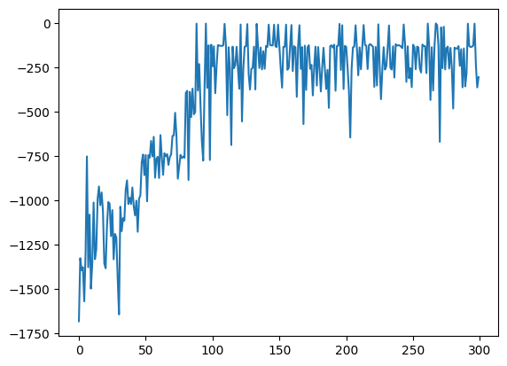

[figure not shown]

```python
epsAgent, eps_score = train_model_eps(DQNAgentEpsGreedy,300)
plot_tuples([(improved_score,"base"),(eps_score,"eps")],"Compare Episilion and Base")
```

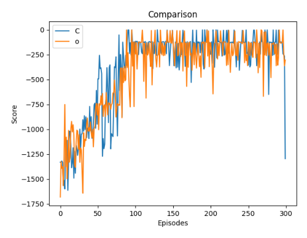

```python
torch.save(epsAgent.policy_net.state_dict(), "./rl_models/epsModel.pt")
showImage("./Imgs_RL/eps_clipping.png")
```

```python
evaluate_model(epsAgent,100)
```

```
Evaluating Episode: 1, Score: -6.52191146639224
Evaluating Episode: 2, Score: -428.82035319323376
Evaluating Episode: 3, Score: -378.7240118946098
Evaluating Episode: 4, Score: -127.04476226843582
Evaluating Episode: 5, Score: -247.83476393311108
Evaluating Episode: 6, Score: -131.83540507645583
Evaluating Episode: 7, Score: -133.3815656584825
Evaluating Episode: 8, Score: -244.2742441122501
Evaluating Episode: 9, Score: -132.69417397307268
Evaluating Episode: 10, Score: -376.0878705911997
Evaluating Episode: 11, Score: -139.96788632523175
Evaluating Episode: 12, Score: -6.192038872005059
Evaluating Episode: 13, Score: -359.38003167871614
Evaluating Episode: 14, Score: -6.6954756107901625
Evaluating Episode: 15, Score: -250.18201890373277
Evaluating Episode: 16, Score: -145.18148576589155
Evaluating Episode: 17, Score: -335.42856279091774
Evaluating Episode: 18, Score: -364.0482466542314
Evaluating Episode: 19, Score: -129.70093120676094
Evaluating Episode: 20, Score: -134.43100161535486
Evaluating Episode: 21, Score: -134.97019001836475
Evaluating Episode: 22, Score: -136.57623038062243
Evaluating Episode: 23, Score: -132.54006844867035
Evaluating Episode: 24, Score: -126.64808646570557
Evaluating Episode: 25, Score: -128.89157275584276
Evaluating Episode: 26, Score: -138.70222188866842
Evaluating Episode: 27, Score: -131.05148779165395
Evaluating Episode: 28, Score: -137.23702031555644
Evaluating Episode: 29, Score: -140.71535576416153
Evaluating Episode: 30, Score: -129.22289055103434
Evaluating Episode: 31, Score: -397.50110375294435
Evaluating Episode: 32, Score: -6.4150585316396205
Evaluating Episode: 33, Score: -142.93161769168566
Evaluating Episode: 34, Score: -272.0509420418009
Evaluating Episode: 35, Score: -131.69010376020742
Evaluating Episode: 36, Score: -142.65470395516948
Evaluating Episode: 37, Score: -260.55674456905916
Evaluating Episode: 38, Score: -131.67636490909297
Evaluating Episode: 39, Score: -366.5728410478583
Evaluating Episode: 40, Score: -146.62864227917586
```

[output cut: 46 more lines]

```
Evaluating Episode: 87, Score: -142.3135551850051
Evaluating Episode: 88, Score: -197.81343548338955
Evaluating Episode: 89, Score: -6.363592572819046
Evaluating Episode: 90, Score: -270.8212461411048
Evaluating Episode: 91, Score: -257.9259828092839
Evaluating Episode: 92, Score: -259.80948411676826
Evaluating Episode: 93, Score: -133.55958352430292
Evaluating Episode: 94, Score: -140.50368114648504
Evaluating Episode: 95, Score: -138.2853680416493
Evaluating Episode: 96, Score: -351.7220932254341
Evaluating Episode: 97, Score: -291.3271589279943
Evaluating Episode: 98, Score: -245.17716921635073
Evaluating Episode: 99, Score: -140.97949187985697
Evaluating Episode: 100, Score: -249.5762971084918
Final Score: -185.0994703336971
```

Observations:

When comparing the training graphs of an epsilon-greedy model with gradient clipping to a simpler DQN, we can see more stabilisation.

1. **Mitigation of Catastrophic Forgetting:**

   The training graph demonstrates improved retention of previously learned information, shown by the fact that there were no sudden and large decreases in performance.
2. **Reduced Fluctuation of Scores:**

### Enhancing Action Space

This only requires editing the DQNAgent

```python
class DQNAgentEpsGreedyAS:
    def __init__(self):
        self.steps = 0
        self.memory = Memory(10000)

        # Greedy Episilon Hyperparams
        self.epsilon       = 1.0
        self.epsilon_decay = 0.98
        self.epsilon_min   = 0.001

        self.batch_size = 256
        self.adamlr = 0.001
        self.gamma = 0.98

        self.numOfAction = 20
        self.action_array = np.concatenate(((-1 *( np.exp(np.linspace(0, 1.09, 10)) - 1))[::-1], np.exp(np.linspace(0, 1.09, 10)) - 1)).tolist()

        self.policy_net = MLP(3, self.numOfAction,self.adamlr)

    def transform_choice(self, num):
        return self.action_array[int(num)]

    def action(self,state):

        sample = np.random.rand()

        if sample > self.epsilon:
            with torch.no_grad():
                choice = float(torch.argmax(self.policy_net(state)).numpy())
                action = self.transform_choice(choice)
        else:
            choice = np.random.choice([n for n in range(self.numOfAction)])
            action = self.transform_choice(choice)

        return choice, action

    def optimize(self):
        if len(self.memory) < self.batch_size:
            return

        batch = self.memory.sample(self.batch_size)
        state, action, reward, next_state = batch
        action = action.type(torch.int64)

        # target
        with torch.no_grad():   # parameters from previous iteration are held fixed
            yi = reward + self.gamma * self.policy_net(next_state).max(1)[0].unsqueeze(1)

        # Q(phi_i, a_i, theta)
        current_state_action = self.policy_net(state).gather(1,action)

        # Back_propagation
        loss = (yi - current_state_action) ** 2
        self.policy_net.optimizer.zero_grad()
        loss.mean().backward()
        nn.utils.clip_grad_norm_(self.policy_net.parameters(), 0.5)
        self.policy_net.optimizer.step()
```

```
Episode: 0, Score: -861.8323603056687, Threshold: 1.0
Episode: 1, Score: -977.9632413882897, Threshold: 0.98
Episode: 2, Score: -1002.2041243995841, Threshold: 0.9603999999999999
Episode: 3, Score: -1826.5246543152543, Threshold: 0.9411919999999999
Episode: 4, Score: -1288.503634732935, Threshold: 0.9223681599999999
Episode: 5, Score: -1478.970993307426, Threshold: 0.9039207967999998
Episode: 6, Score: -782.3274432344673, Threshold: 0.8858423808639998
Episode: 7, Score: -1250.884811600396, Threshold: 0.8681255332467198
Episode: 8, Score: -1648.4508045805835, Threshold: 0.8507630225817854
Episode: 9, Score: -1175.7128593906061, Threshold: 0.8337477621301497
Episode: 10, Score: -911.1186058033562, Threshold: 0.8170728068875467
Episode: 11, Score: -1034.6247763649965, Threshold: 0.8007313507497957
Episode: 12, Score: -1464.0779385946246, Threshold: 0.7847167237347998
Episode: 13, Score: -1096.447503878644, Threshold: 0.7690223892601038
Episode: 14, Score: -1269.0280285675835, Threshold: 0.7536419414749017
Episode: 15, Score: -1623.2806428086988, Threshold: 0.7385691026454037
Episode: 16, Score: -1248.2815267479396, Threshold: 0.7237977205924956
Episode: 17, Score: -994.2486013336264, Threshold: 0.7093217661806457
Episode: 18, Score: -1662.1429165701006, Threshold: 0.6951353308570327
Episode: 19, Score: -1548.8091705270713, Threshold: 0.6812326242398921
Episode: 20, Score: -1192.7378572325988, Threshold: 0.6676079717550942
Episode: 21, Score: -1176.1876110135274, Threshold: 0.6542558123199923
Episode: 22, Score: -1173.7644032277567, Threshold: 0.6411706960735924
Episode: 23, Score: -1018.2137410648238, Threshold: 0.6283472821521205
Episode: 24, Score: -903.8758574960482, Threshold: 0.6157803365090782
Episode: 25, Score: -1055.8923744255203, Threshold: 0.6034647297788965
Episode: 26, Score: -1051.3890355658853, Threshold: 0.5913954351833186
Episode: 27, Score: -1460.7604902988487, Threshold: 0.5795675264796523
Episode: 28, Score: -1348.5887688516852, Threshold: 0.5679761759500592
Episode: 29, Score: -1020.6145522942398, Threshold: 0.5566166524310581
Episode: 30, Score: -1144.992197006925, Threshold: 0.5454843193824369
Episode: 31, Score: -909.6545281974256, Threshold: 0.5345746329947881
Episode: 32, Score: -787.3015145664804, Threshold: 0.5238831403348924
Episode: 33, Score: -867.1966014328134, Threshold: 0.5134054775281945
Episode: 34, Score: -1183.2137442826752, Threshold: 0.5031373679776306
Episode: 35, Score: -1054.7374018939367, Threshold: 0.493074620618078
Episode: 36, Score: -1033.8572832184145, Threshold: 0.48321312820571644
Episode: 37, Score: -1033.9439425642177, Threshold: 0.4735488656416021
Episode: 38, Score: -1103.7476332359486, Threshold: 0.46407788832877006
Episode: 39, Score: -968.6618743318384, Threshold: 0.45479633056219465
```

[output cut: 245 more lines]

```
Episode: 285, Score: -235.44095596675055, Threshold: 0.003158141411002513
Episode: 286, Score: -330.9494608166211, Threshold: 0.003094978582782463
Episode: 287, Score: -122.7793069122554, Threshold: 0.0030330790111268136
Episode: 288, Score: -121.04610175915788, Threshold: 0.0029724174309042773
Episode: 289, Score: -2.7874775874173814, Threshold: 0.002912969082286192
Episode: 290, Score: -235.1411433801053, Threshold: 0.002854709700640468
Episode: 291, Score: -277.04536448818254, Threshold: 0.0027976155066276585
Episode: 292, Score: -120.01304462335624, Threshold: 0.0027416631964951054
Episode: 293, Score: -127.05686603823263, Threshold: 0.0026868299325652034
Episode: 294, Score: -289.9318921490468, Threshold: 0.002633093333913899
Episode: 295, Score: -116.42743710179931, Threshold: 0.002580431467235621
Episode: 296, Score: -128.4256229388928, Threshold: 0.0025288228378909086
Episode: 297, Score: -129.75843210733254, Threshold: 0.0024782463811330903
Episode: 298, Score: -119.69071345156638, Threshold: 0.0024286814535104282
Episode: 299, Score: -238.77235133720902, Threshold: 0.0023801078244402194
```

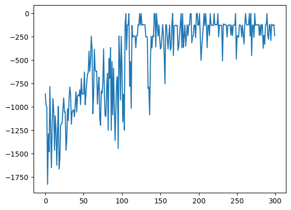

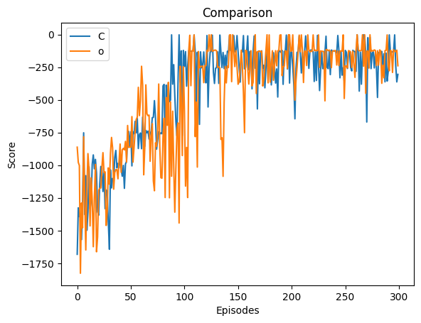

```python
asAgent, as_score = train_model_eps(DQNAgentEpsGreedyAS,300)
plot_tuples([(eps_score,"base"),(as_score,"action")],"Compare Increased Action Array")
```

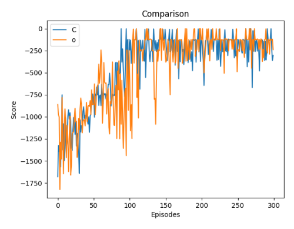

```python
torch.save(asAgent.policy_net.state_dict(), "./rl_models/eps_action_model.pt")
showImage("./Imgs_RL/actionarray.png")
```

```python
evaluate_model(asAgent,100)
```

```
Evaluating Episode: 1, Score: -360.78961258968786
Evaluating Episode: 2, Score: -122.38719155656338
Evaluating Episode: 3, Score: -243.44224126089134
Evaluating Episode: 4, Score: -126.52933637399833
Evaluating Episode: 5, Score: -128.6612468782026
Evaluating Episode: 6, Score: -3.1326407882633283
Evaluating Episode: 7, Score: -124.75503339931856
Evaluating Episode: 8, Score: -242.636010429231
Evaluating Episode: 9, Score: -127.64899731619988
Evaluating Episode: 10, Score: -125.41580794131399
Evaluating Episode: 11, Score: -121.21512173249374
Evaluating Episode: 12, Score: -127.78351388588779
Evaluating Episode: 13, Score: -119.12153274595357
Evaluating Episode: 14, Score: -121.46858733304083
Evaluating Episode: 15, Score: -132.63969494596336
Evaluating Episode: 16, Score: -490.04706571847294
Evaluating Episode: 17, Score: -124.02186810245344
Evaluating Episode: 18, Score: -254.80615549384908
Evaluating Episode: 19, Score: -129.1419701111082
Evaluating Episode: 20, Score: -347.2431583652955
Evaluating Episode: 21, Score: -118.70264283759381
Evaluating Episode: 22, Score: -326.42137964307636
Evaluating Episode: 23, Score: -123.42088703191597
Evaluating Episode: 24, Score: -119.69532737527608
Evaluating Episode: 25, Score: -1.4293201252094945
Evaluating Episode: 26, Score: -264.09992808947527
Evaluating Episode: 27, Score: -257.09501207465274
Evaluating Episode: 28, Score: -246.5370075405787
Evaluating Episode: 29, Score: -126.41709005879977
Evaluating Episode: 30, Score: -232.00862733756227
Evaluating Episode: 31, Score: -116.54856756352862
Evaluating Episode: 32, Score: -124.34010052612078
Evaluating Episode: 33, Score: -1.4677410249790506
Evaluating Episode: 34, Score: -127.14351216970752
Evaluating Episode: 35, Score: -358.75771133218296
Evaluating Episode: 36, Score: -125.27226885019982
Evaluating Episode: 37, Score: -2.3295347661322587
Evaluating Episode: 38, Score: -124.05817334163795
Evaluating Episode: 39, Score: -125.56040004760536
Evaluating Episode: 40, Score: -121.41750829523214
```

[output cut: 46 more lines]

```
Evaluating Episode: 87, Score: -126.33577631138621
Evaluating Episode: 88, Score: -126.98413434126445
Evaluating Episode: 89, Score: -245.40224711309963
Evaluating Episode: 90, Score: -118.77553023772543
Evaluating Episode: 91, Score: -115.43344151808317
Evaluating Episode: 92, Score: -115.88926956168315
Evaluating Episode: 93, Score: -127.16003896980274
Evaluating Episode: 94, Score: -115.80293234616313
Evaluating Episode: 95, Score: -348.1621352477874
Evaluating Episode: 96, Score: -257.5322074135525
Evaluating Episode: 97, Score: -343.2511152518756
Evaluating Episode: 98, Score: -127.30009353606876
Evaluating Episode: 99, Score: -125.72503652589835
Evaluating Episode: 100, Score: -363.41519736325944
Final Score: -161.9948015143182
```

```python
visualize_model(asAgent,3)
```

```
Visualizing Episode: 1, Score: -126.84684030612024
Visualizing Episode: 2, Score: -1.7658373225375716
Visualizing Episode: 3, Score: -252.42271059466992
```

### Enchancing Model Architecture

While the model is quite stable as of now, we seek to further stabilise it by make some architectural changes

#### Double DQN

**Problem with Simple DQN**

In a standard Deep Q-Network (DQN), during the Q-value estimation for the next state, the same network is used to both select and evaluate the best action. This can lead to overestimation of Q-values, especially in scenarios where the Q-values are noisy or subject to fluctuations.

**Solution: Decouple Action Selection and Evaluation**

Double DQN introduces a simple yet effective modification to the Q-value estimation process. Instead of relying on a single network for both action selection and evaluation, it maintains two separate networks: one for selecting the best action and another for evaluating that action's Q-value.

**Modifying DQN Architecture for Double DQN**

Target Evaluation Network ($Q_{\text{eval}}$):

- Separate neural network for evaluating Q-values of the selected actions.
- Both networks should be initialized with the same parameters.
- Parameters are periodically synchronized from the action selection network.

Bellman Update:

- Update the Q-value of the current state-action pair based on the reward and the discounted maximum Q-value from the target evaluation network.

#### Rationale Behind using Two Networks:

Having two networks to make a decision might seem counter intuitive but it can actually stabilise training time.

Without Target Network

[figure not shown]

With Target network

[figure not shown]

#### Loss Function

For the loss function, we will be using Huber Loss. Huber loss is calculated using the outputs from the target and policy network. Based on the Gamma parameter used, it can behave more like MSE for small errors and MAE for large errors. We will use this loss to backpropogate the policy network. We will update the target network using a weighted sum of the new policy values and the current target values

```python
class DoubleDQNAgent:
    def __init__(self):
        self.steps = 0
        self.memory = Memory(10000)

        # Greedy Episilon Hyperparams
        self.epsilon       = 1.0
        self.epsilon_decay = 0.98
        self.epsilon_min   = 0.001

        self.batch_size = 256
        self.adamlr = 0.001
        self.targetlr = 0.01
        self.gamma = 0.98

        self.numOfAction = 20
        self.action_array = np.concatenate(((-1 *( np.exp(np.linspace(0, 1.09, 10)) - 1))[::-1], np.exp(np.linspace(0, 1.09, 10)) - 1)).tolist()

        self.policy_net = MLP(3, self.numOfAction,self.adamlr)
        self.target_net = MLP(3, self.numOfAction,self.adamlr)
        self.target_net.load_state_dict(self.policy_net.state_dict())

    def transform_choice(self, num):
        return self.action_array[int(num)]

    def action(self,state):

        sample = np.random.rand()

        if sample > self.epsilon:
            with torch.no_grad():
                choice = float(torch.argmax(self.policy_net(state)).numpy())
                action = self.transform_choice(choice)
        else:
            choice = np.random.choice([n for n in range(self.numOfAction)])
            action = self.transform_choice(choice)

        return choice, action

    def optimize(self):
        if len(self.memory) < self.batch_size:
            return

        batch = self.memory.sample(self.batch_size)
        state, action, reward, next_state = batch
        action = action.type(torch.int64)

        with torch.no_grad():
            expected_q = self.target_net(next_state).max(1)[0].unsqueeze(1)
            expected = reward + self.gamma * expected_q

        # Actual values - Policy Net
        actual = self.policy_net(state).gather(1,action)

        # Back_propagation
        loss = F.smooth_l1_loss(actual, expected)
        self.policy_net.optimizer.zero_grad()
        loss.mean().backward()
        nn.utils.clip_grad_norm_(self.policy_net.parameters(), 0.5)
        self.policy_net.optimizer.step()

        for target_param,param in zip(self.target_net.parameters(),self.policy_net.parameters()):
            target_param.data.copy_(target_param.data * (1.0 - self.targetlr) + param.data * self.targetlr)
```

```
Episode: 0, Score: -1720.2270408142153, Threshold: 1.0
Episode: 1, Score: -879.9630781382018, Threshold: 0.98
Episode: 2, Score: -1296.3623037559014, Threshold: 0.9603999999999999
Episode: 3, Score: -903.1763556133876, Threshold: 0.9411919999999999
Episode: 4, Score: -1059.955271097056, Threshold: 0.9223681599999999
Episode: 5, Score: -1484.446923097765, Threshold: 0.9039207967999998
Episode: 6, Score: -1292.6872219982292, Threshold: 0.8858423808639998
Episode: 7, Score: -1054.1123517864637, Threshold: 0.8681255332467198
Episode: 8, Score: -1580.0339088996536, Threshold: 0.8507630225817854
Episode: 9, Score: -1356.7580300869038, Threshold: 0.8337477621301497
Episode: 10, Score: -899.3799357722331, Threshold: 0.8170728068875467
Episode: 11, Score: -942.3626632774153, Threshold: 0.8007313507497957
Episode: 12, Score: -737.3833816728004, Threshold: 0.7847167237347998
Episode: 13, Score: -884.6281329942175, Threshold: 0.7690223892601038
Episode: 14, Score: -1194.047420887284, Threshold: 0.7536419414749017
Episode: 15, Score: -920.4576088156955, Threshold: 0.7385691026454037
Episode: 16, Score: -761.6859141809356, Threshold: 0.7237977205924956
Episode: 17, Score: -1053.7234719576154, Threshold: 0.7093217661806457
Episode: 18, Score: -1095.118824614367, Threshold: 0.6951353308570327
Episode: 19, Score: -903.9362501236927, Threshold: 0.6812326242398921
Episode: 20, Score: -926.8803626126414, Threshold: 0.6676079717550942
Episode: 21, Score: -1116.9881778258148, Threshold: 0.6542558123199923
Episode: 22, Score: -897.1889886129989, Threshold: 0.6411706960735924
Episode: 23, Score: -882.2707128578173, Threshold: 0.6283472821521205
Episode: 24, Score: -627.993043210483, Threshold: 0.6157803365090782
Episode: 25, Score: -372.32993821900357, Threshold: 0.6034647297788965
Episode: 26, Score: -954.8645210504477, Threshold: 0.5913954351833186
Episode: 27, Score: -738.7129928745436, Threshold: 0.5795675264796523
Episode: 28, Score: -756.510902322908, Threshold: 0.5679761759500592
Episode: 29, Score: -847.4515996764688, Threshold: 0.5566166524310581
Episode: 30, Score: -506.35034221629843, Threshold: 0.5454843193824369
Episode: 31, Score: -839.5060256452258, Threshold: 0.5345746329947881
Episode: 32, Score: -840.6147836700715, Threshold: 0.5238831403348924
Episode: 33, Score: -375.7488107600246, Threshold: 0.5134054775281945
Episode: 34, Score: -488.01096735971623, Threshold: 0.5031373679776306
Episode: 35, Score: -374.1858810443215, Threshold: 0.493074620618078
Episode: 36, Score: -389.6005071457724, Threshold: 0.48321312820571644
Episode: 37, Score: -121.43082504590069, Threshold: 0.4735488656416021
Episode: 38, Score: -511.3070828136455, Threshold: 0.46407788832877006
Episode: 39, Score: -264.701756795172, Threshold: 0.45479633056219465
```

[output cut: 245 more lines]

```
Episode: 285, Score: -123.25859923893012, Threshold: 0.003158141411002513
Episode: 286, Score: -124.62907394800955, Threshold: 0.003094978582782463
Episode: 287, Score: -118.07556804528127, Threshold: 0.0030330790111268136
Episode: 288, Score: -123.61855833332105, Threshold: 0.0029724174309042773
Episode: 289, Score: -252.91257351117127, Threshold: 0.002912969082286192
Episode: 290, Score: -127.05450157454152, Threshold: 0.002854709700640468
Episode: 291, Score: -2.5759639806418946, Threshold: 0.0027976155066276585
Episode: 292, Score: -121.9332004294131, Threshold: 0.0027416631964951054
Episode: 293, Score: -122.10436201997602, Threshold: 0.0026868299325652034
Episode: 294, Score: -121.99828003501452, Threshold: 0.002633093333913899
Episode: 295, Score: -317.9722323650689, Threshold: 0.002580431467235621
Episode: 296, Score: -382.4309976547135, Threshold: 0.0025288228378909086
Episode: 297, Score: -241.89491398962667, Threshold: 0.0024782463811330903
Episode: 298, Score: -118.62338948773676, Threshold: 0.0024286814535104282
Episode: 299, Score: -127.18046179295924, Threshold: 0.0023801078244402194
```

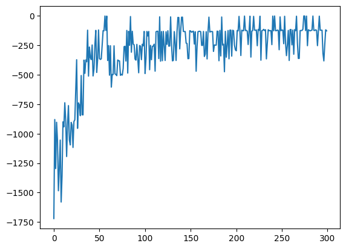

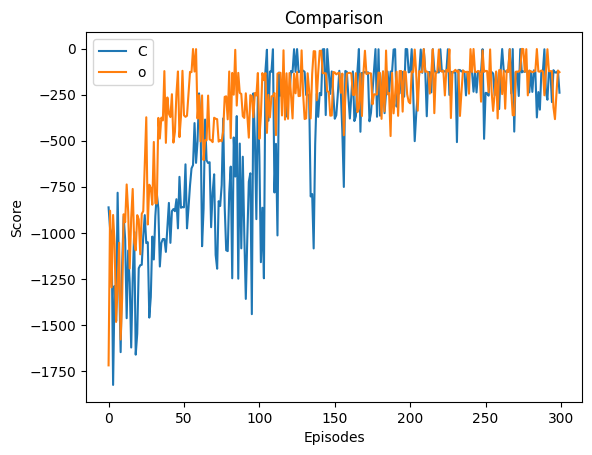

```python
DDAgent, ddqn_score = train_model_eps(DoubleDQNAgent,300)
plot_tuples([(as_score,"base"),(ddqn_score,"action")],"Compare Double DQN")
```

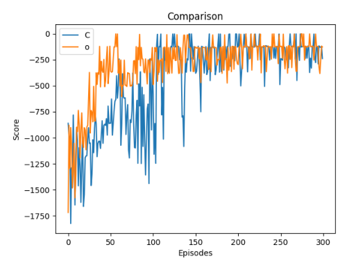

```python
torch.save(DDAgent.policy_net.state_dict(), "./rl_models/double_dqn.pt")
showImage("./Imgs_RL/ddqn.png")
```

```python
evaluate_model(DDAgent,100)
```

```
Evaluating Episode: 1, Score: -132.44311160159268
Evaluating Episode: 2, Score: -133.848964565773
Evaluating Episode: 3, Score: -123.43368971899999
Evaluating Episode: 4, Score: -251.41484798415826
Evaluating Episode: 5, Score: -129.9899541733548
Evaluating Episode: 6, Score: -8.725552251734054
Evaluating Episode: 7, Score: -132.89988956976507
Evaluating Episode: 8, Score: -242.72683304932437
Evaluating Episode: 9, Score: -133.3335926104606
Evaluating Episode: 10, Score: -366.9640009047146
Evaluating Episode: 11, Score: -8.742260311312142
Evaluating Episode: 12, Score: -133.8247788899434
Evaluating Episode: 13, Score: -133.55853040907573
Evaluating Episode: 14, Score: -279.7122677375049
Evaluating Episode: 15, Score: -10.769411274796447
Evaluating Episode: 16, Score: -252.79057778831626
Evaluating Episode: 17, Score: -133.09159953673912
Evaluating Episode: 18, Score: -11.359946725670483
Evaluating Episode: 19, Score: -132.52267161434418
Evaluating Episode: 20, Score: -129.6967052921864
Evaluating Episode: 21, Score: -121.8944933425897
Evaluating Episode: 22, Score: -251.9420767071638
Evaluating Episode: 23, Score: -259.2405743523838
Evaluating Episode: 24, Score: -241.49226382074724
Evaluating Episode: 25, Score: -131.6690288897437
Evaluating Episode: 26, Score: -9.179513301903976
Evaluating Episode: 27, Score: -259.07057329841587
Evaluating Episode: 28, Score: -336.8626548607074
Evaluating Episode: 29, Score: -236.95692945163827
Evaluating Episode: 30, Score: -124.92470942695215
Evaluating Episode: 31, Score: -8.793251212847439
Evaluating Episode: 32, Score: -125.47200007747465
Evaluating Episode: 33, Score: -8.730015242138236
Evaluating Episode: 34, Score: -257.10848663649534
Evaluating Episode: 35, Score: -129.08424820114925
Evaluating Episode: 36, Score: -135.1129410151572
Evaluating Episode: 37, Score: -133.28397330499703
Evaluating Episode: 38, Score: -8.75555744263936
Evaluating Episode: 39, Score: -139.25931615558673
Evaluating Episode: 40, Score: -360.0774364207425
```

[output cut: 46 more lines]

```
Evaluating Episode: 87, Score: -8.994535449490604
Evaluating Episode: 88, Score: -249.38525223982833
Evaluating Episode: 89, Score: -128.9789775318166
Evaluating Episode: 90, Score: -376.96664986236675
Evaluating Episode: 91, Score: -124.98527321256886
Evaluating Episode: 92, Score: -274.07542240772807
Evaluating Episode: 93, Score: -126.81215185952387
Evaluating Episode: 94, Score: -121.59323876478003
Evaluating Episode: 95, Score: -132.38670254584287
Evaluating Episode: 96, Score: -136.30570298467163
Evaluating Episode: 97, Score: -249.85606576813964
Evaluating Episode: 98, Score: -237.6213096465926
Evaluating Episode: 99, Score: -10.312292494030565
Evaluating Episode: 100, Score: -134.26386811342817
Final Score: -150.73909456883962
```

```python
visualize_model(DDAgent,3)
```

```
Visualizing Episode: 1, Score: -8.456244914503419
Visualizing Episode: 2, Score: -8.60563807086996
Visualizing Episode: 3, Score: -136.2381554988296
```

#### Observation:

**Stability:**

This model is definitely less prone to sudden lapses. The accuracy rarely deteriorates although it oscillates from -250 to 0. This is slightly concerning but i think its not a deal breaker.

**Training Speed:**

One of the biggest improvements is training time. Compared to the previous DQN which got to good accuracy after 100 episodes, this modle reached that in around 60 episodes.

**Performance:**

With a 100 epoch average of -150, we are literally the #7 best model for this Pendulum Problem according to the github leaderboard shown earlier. This is a significant improvement from the -160 I got earlier

#### Double Dueling DQN

[figure not shown]

Dueling architectures aim to address the limitations of DDQN by separating the estimation of the value and advantage functions, providing more stable and accurate Q-value predictions.

1. Reducing Overestimation Bias:
   - The dueling architecture helps mitigate overestimation bias by separating the estimation of state values and action advantages.
2. Enhanced Stability in Training:
   - D3QN tends to exhibit improved stability during training, reducing the risk of oscillations in learning.

This can easily be implemeted by modifying the MLP model.

```python
class DDQN_MLP(nn.Module):
    def __init__(self, inp, out, lr):
        super(DDQN_MLP, self).__init__()

        self.layer1 = nn.Linear(inp, 32)
        self.layer2 = nn.Linear(32, 64)

        self.value_stream = nn.Sequential(
            nn.Linear(64, 64),
            nn.LeakyReLU(inplace=True),
            nn.Linear(64, 1)
        )

        self.advantage_stream = nn.Sequential(
            nn.Linear(64, 64),
            nn.LeakyReLU(inplace=True),
            nn.Linear(64, out)
        )

        self.lr = lr
        self.optimizer = optim.Adam(self.parameters(), lr=self.lr)

    def forward(self, x):
        x = self.layer1(x)
        x = F.leaky_relu(x)
        x = self.layer2(x)
        x = F.leaky_relu(x)
        # x = self.layer3(x)
        # x = F.leaky_relu(x)

        values = self.value_stream(x)
        advantages = self.advantage_stream(x)
        q_values = values + advantages - advantages.mean()

        return q_values
```

```python
class D3DQNAgent:
    def __init__(self):
        self.steps = 0
        self.memory = Memory(10000)

        # Greedy Episilon Hyperparams
        self.epsilon       = 1.0
        self.epsilon_decay = 0.98
        self.epsilon_min   = 0.001

        self.batch_size = 256
        self.adamlr = 0.001
        self.targetlr = 0.01
        self.gamma = 0.98

        self.numOfAction = 20
        self.action_array = np.concatenate(((-1 *( np.exp(np.linspace(0, 1.09, 10)) - 1))[::-1], np.exp(np.linspace(0, 1.09, 10)) - 1)).tolist()

        self.policy_net = DDQN_MLP(3, self.numOfAction,self.adamlr)
        self.target_net = DDQN_MLP(3, self.numOfAction,self.adamlr)
        self.target_net.load_state_dict(self.policy_net.state_dict())

    def transform_choice(self, num):
        return self.action_array[int(num)]

    def action(self,state):

        sample = np.random.rand()

        if sample > self.epsilon:
            with torch.no_grad():
                choice = float(torch.argmax(self.policy_net(state)).numpy())
                action = self.transform_choice(choice)
        else:
            choice = np.random.choice([n for n in range(self.numOfAction)])
            action = self.transform_choice(choice)

        return choice, action

    def optimize(self):
        if len(self.memory) < self.batch_size:
            return

        batch = self.memory.sample(self.batch_size)
        state, action, reward, next_state = batch
        action = action.type(torch.int64)

        with torch.no_grad():
            expected_q = self.target_net(next_state).max(1)[0].unsqueeze(1)
            expected = reward + self.gamma * expected_q

        # Actual values - Policy Net
        actual = self.policy_net(state).gather(1,action)

        # Back_propagation
        loss = F.smooth_l1_loss(actual, expected)
        self.policy_net.optimizer.zero_grad()
        loss.mean().backward()
        nn.utils.clip_grad_norm_(self.policy_net.parameters(), 0.5)
        self.policy_net.optimizer.step()

        for target_param,param in zip(self.target_net.parameters(),self.policy_net.parameters()):
            target_param.data.copy_(target_param.data * (1.0 - self.targetlr) + param.data * self.targetlr)
```

```
Episode: 0, Score: -882.9720168590786, Threshold: 1.0
Episode: 1, Score: -1068.1073584916733, Threshold: 0.98
Episode: 2, Score: -1043.747252454962, Threshold: 0.9603999999999999
Episode: 3, Score: -1614.8689938988646, Threshold: 0.9411919999999999
Episode: 4, Score: -1596.900833310135, Threshold: 0.9223681599999999
Episode: 5, Score: -1066.2255004437843, Threshold: 0.9039207967999998
Episode: 6, Score: -1568.8463418482115, Threshold: 0.8858423808639998
Episode: 7, Score: -1713.1005602422458, Threshold: 0.8681255332467198
Episode: 8, Score: -1653.0370023003052, Threshold: 0.8507630225817854
Episode: 9, Score: -1184.1966162149529, Threshold: 0.8337477621301497
Episode: 10, Score: -1197.8968483538235, Threshold: 0.8170728068875467
Episode: 11, Score: -1222.4327573430426, Threshold: 0.8007313507497957
Episode: 12, Score: -1083.775666196598, Threshold: 0.7847167237347998
Episode: 13, Score: -791.8370683951285, Threshold: 0.7690223892601038
Episode: 14, Score: -1273.95864899669, Threshold: 0.7536419414749017
Episode: 15, Score: -863.7952267257812, Threshold: 0.7385691026454037
Episode: 16, Score: -1380.1309974217722, Threshold: 0.7237977205924956
Episode: 17, Score: -1051.1079822110923, Threshold: 0.7093217661806457
Episode: 18, Score: -1023.7394980074866, Threshold: 0.6951353308570327
Episode: 19, Score: -912.812992630354, Threshold: 0.6812326242398921
Episode: 20, Score: -894.4487149638567, Threshold: 0.6676079717550942
Episode: 21, Score: -1048.4615161624986, Threshold: 0.6542558123199923
Episode: 22, Score: -760.3607674842425, Threshold: 0.6411706960735924
Episode: 23, Score: -502.4486229664367, Threshold: 0.6283472821521205
Episode: 24, Score: -632.0473837603671, Threshold: 0.6157803365090782
Episode: 25, Score: -388.6753096646986, Threshold: 0.6034647297788965
Episode: 26, Score: -380.12021599010956, Threshold: 0.5913954351833186
Episode: 27, Score: -1010.3611745891053, Threshold: 0.5795675264796523
Episode: 28, Score: -720.910316544517, Threshold: 0.5679761759500592
Episode: 29, Score: -418.5790580410458, Threshold: 0.5566166524310581
Episode: 30, Score: -251.4732428913829, Threshold: 0.5454843193824369
Episode: 31, Score: -376.3165204927492, Threshold: 0.5345746329947881
Episode: 32, Score: -732.0473633886388, Threshold: 0.5238831403348924
Episode: 33, Score: -245.65713411944932, Threshold: 0.5134054775281945
Episode: 34, Score: -479.40610446606337, Threshold: 0.5031373679776306
Episode: 35, Score: -478.43570621374414, Threshold: 0.493074620618078
Episode: 36, Score: -615.5947930948005, Threshold: 0.48321312820571644
Episode: 37, Score: -378.49884813040853, Threshold: 0.4735488656416021
Episode: 38, Score: -488.8966484774073, Threshold: 0.46407788832877006
Episode: 39, Score: -249.1219698060636, Threshold: 0.45479633056219465
```

[output cut: 245 more lines]

```
Episode: 285, Score: -129.0762146855694, Threshold: 0.003158141411002513
Episode: 286, Score: -4.406472349912652, Threshold: 0.003094978582782463
Episode: 287, Score: -224.0571751987684, Threshold: 0.0030330790111268136
Episode: 288, Score: -4.630508079124666, Threshold: 0.0029724174309042773
Episode: 289, Score: -241.62632318654815, Threshold: 0.002912969082286192
Episode: 290, Score: -120.56051705012683, Threshold: 0.002854709700640468
Episode: 291, Score: -6.620679187502974, Threshold: 0.0027976155066276585
Episode: 292, Score: -127.5508422045304, Threshold: 0.0027416631964951054
Episode: 293, Score: -3.5949275600026067, Threshold: 0.0026868299325652034
Episode: 294, Score: -132.57343994297838, Threshold: 0.002633093333913899
Episode: 295, Score: -7.126901871611591, Threshold: 0.002580431467235621
Episode: 296, Score: -130.76237563645333, Threshold: 0.0025288228378909086
Episode: 297, Score: -119.92543608847048, Threshold: 0.0024782463811330903
Episode: 298, Score: -126.43295055693277, Threshold: 0.0024286814535104282
Episode: 299, Score: -3.7939314722656983, Threshold: 0.0023801078244402194
```

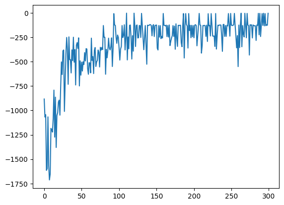

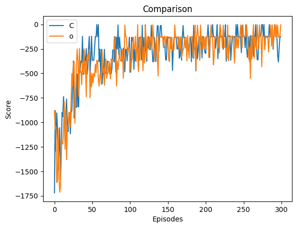

```python
d3Agent, d3qn_score = train_model_eps(D3DQNAgent,300)
plot_tuples([(ddqn_score,"base"),(d3qn_score,"action")],"Compare Dueling DQN")
```

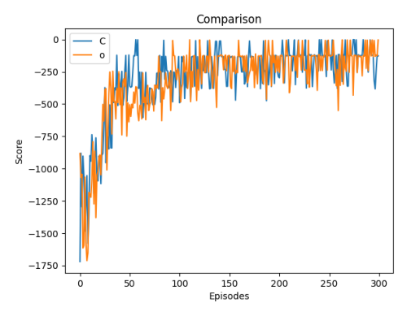

```python
torch.save(d3Agent.policy_net.state_dict(), "./rl_models/d3_dqn.pt")
showImage("./Imgs_RL/d3qn.png")
```

```python
evaluate_model(d3Agent,100)
```

```
Evaluating Episode: 1, Score: -127.59256772621004
Evaluating Episode: 2, Score: -239.81248402371136
Evaluating Episode: 3, Score: -238.50409049633672
Evaluating Episode: 4, Score: -259.6025446165501
Evaluating Episode: 5, Score: -234.36524054949578
Evaluating Episode: 6, Score: -242.11989743389043
Evaluating Episode: 7, Score: -255.5806229434536
Evaluating Episode: 8, Score: -235.01063982145246
Evaluating Episode: 9, Score: -120.38471857947727
Evaluating Episode: 10, Score: -118.96169287981972
Evaluating Episode: 11, Score: -245.2257182042775
Evaluating Episode: 12, Score: -1.608038043264248
Evaluating Episode: 13, Score: -120.41615863309677
Evaluating Episode: 14, Score: -247.67468755660587
Evaluating Episode: 15, Score: -127.84812739998765
Evaluating Episode: 16, Score: -129.12103517328725
Evaluating Episode: 17, Score: -246.53165757065838
Evaluating Episode: 18, Score: -2.1141059999520984
Evaluating Episode: 19, Score: -362.9283969665194
Evaluating Episode: 20, Score: -1.8854551369325065
Evaluating Episode: 21, Score: -375.74061607839894
Evaluating Episode: 22, Score: -115.14162999675648
Evaluating Episode: 23, Score: -125.94995381142644
Evaluating Episode: 24, Score: -124.18054772889302
Evaluating Episode: 25, Score: -248.5713493011811
Evaluating Episode: 26, Score: -117.96243035141902
Evaluating Episode: 27, Score: -124.9787843105126
Evaluating Episode: 28, Score: -2.539241766685915
Evaluating Episode: 29, Score: -238.4536023654143
Evaluating Episode: 30, Score: -263.2193732019183
Evaluating Episode: 31, Score: -2.389291177247148
Evaluating Episode: 32, Score: -361.4846302679067
Evaluating Episode: 33, Score: -116.59832506979689
Evaluating Episode: 34, Score: -125.46359376189405
Evaluating Episode: 35, Score: -120.25877817262163
Evaluating Episode: 36, Score: -129.09030825770327
Evaluating Episode: 37, Score: -125.37407095474036
Evaluating Episode: 38, Score: -120.14370050154841
Evaluating Episode: 39, Score: -122.2980895305757
Evaluating Episode: 40, Score: -118.71687237125435
```

[output cut: 46 more lines]

```
Evaluating Episode: 87, Score: -246.4409684057646
Evaluating Episode: 88, Score: -439.62104285215946
Evaluating Episode: 89, Score: -123.22687089773007
Evaluating Episode: 90, Score: -228.17380827592038
Evaluating Episode: 91, Score: -126.7939162690368
Evaluating Episode: 92, Score: -233.25106431077347
Evaluating Episode: 93, Score: -223.82144766454732
Evaluating Episode: 94, Score: -1.5536424208576494
Evaluating Episode: 95, Score: -121.6620458809439
Evaluating Episode: 96, Score: -236.23434887653409
Evaluating Episode: 97, Score: -129.11318920243428
Evaluating Episode: 98, Score: -125.47101873526412
Evaluating Episode: 99, Score: -3.3631228484738966
Evaluating Episode: 100, Score: -1.5720329908289754
Final Score: -168.80958158263027
```

Observations:

- Dueling Double DQN is nearly identical to Double DQn in terms of performancs and stability.

While Dueling Double Deep Q-Network (D3QN) is a superior architecture, its impact might be limited when applied to the Pendulum problem. This is because:

**Complexity of Pendulum Dynamics:**

- The Pendulum problem has relatively simple dynamics compared to more complex environments. The advantages of D3QN, such as reduced overestimation bias and enhanced stability, might not be as important when the underlying dynamics are straightforward.

**Limited Advantage Separation:**

- In the Pendulum environment, the separation of value and advantage functions in the dueling architecture may not provide a significant advantage. The advantage stream might not effectively capture nuanced differences between actions, limiting the benefits of the dueling structure.

### Exhancing Memory Sampling

Efficient learning relies on effective exploration and utilization of past experiences stored in the replay buffer.

Improvement: In standard DQN training, experiences are uniformly sampled from the replay buffer, treating all transitions equally. I would like to change this by introducing Prioritized Replay which adopts a dynamic approach to memory sampling by assigning higher probabilities to experiences with larger TD errors.

Benefits:

1. **Focused Learning:** Prioritizing experiences with higher learning potential.
2. **Efficient Exploration:** Emphasizing crucial transitions for more effective training.

#### Prioritized Experience Replay

Some experiences are more valueable than others. To take into account the importance of some experiences, we introduce prioritised experience replay.

How do we give a value to an experience?

- We give a higher value to experiences that lead to higher loss. We use the formula $ \text{abs}(\text{TD error}) + \text{constant} $
- A constant is added to the priority value so as to make sure some samples being given 0 priority

Stocashtic Priorizations

- If we implement the above system without any modification, we would find only some experiences being used and some not at all.
- To mitigate this, we assign a probability to each experience this formula

[figure not shown]

Over here, "a" is a hyperparameter to be tuned.

```python
class PERMemory(object):

    def __init__(self, maxlen):
        self.buffer = deque([], maxlen=maxlen)
        self.priorities = deque([], maxlen=maxlen)
        # using deque from collections but possible implement from scratch
    def push(self, transition):
        self.buffer.append(transition)
        self.priorities.append(max(self.priorities, default=1))

    def get_probs(self, alpha):
        #print(self.priorities)
        priorities = np.array(self.priorities) ** alpha
        sample_probs = priorities/ np.sum(priorities)
        return sample_probs

    def get_importance(self, probs):
        impt = 1/len(self.buffer) * 1/probs
        impt = impt / max(impt)
        return impt

    def sample(self, batch_size,alpha=1):
        sample_probs = self.get_probs(alpha)
        samples_index = random.choices(range(len(self.buffer)), k = batch_size, weights = sample_probs)
        #print(np.array(self.buffer.))
        #mini_batch = np.array(self.buffer)[samples_index]
        mini_batch = [self.buffer[idx] for idx in samples_index]
        importance = self.get_importance(sample_probs[samples_index])

        #mini_batch = random.sample(self.buffer, batch_size)
        states, actions, rewards, next_states = [], [], [], []

        for transition in mini_batch:
            s, a, r, ns = transition
            states.append(s) # s is a tensor not a regular element
            actions.append([a])
            rewards.append([r])
            next_states.append(ns)

        states = torch.stack(states)
        actions = torch.tensor(actions, dtype=torch.float)
        rewards = torch.tensor(rewards, dtype=torch.float)
        next_states = torch.stack(next_states)
        return states, actions, rewards, next_states, torch.tensor(importance), samples_index

    def set_priorities(self, index, error, offset= 0.1):
        for i,e in zip(index, error):
            if isinstance(e,np.ndarray):
                e = e[0]
            self.priorities[i] = abs(e) + offset

    def __len__(self):
        return len(self.buffer)
```

```python
class PERDoubleDQNAgent:
    def __init__(self):
        self.steps = 0
        self.memory = PERMemory(10000)

        # Greedy Episilon Hyperparams
        self.epsilon       = 1.0
        self.epsilon_decay = 0.98
        self.epsilon_min   = 0.001

        self.batch_size = 256
        self.adamlr = 0.001
        self.targetlr = 0.01
        self.gamma = 0.98

        self.numOfAction = 20
        self.action_array = np.concatenate(((-1 *( np.exp(np.linspace(0, 1.09, 10)) - 1))[::-1], np.exp(np.linspace(0, 1.09, 10)) - 1)).tolist()

        self.policy_net = MLP(3, self.numOfAction,self.adamlr)
        self.target_net = MLP(3, self.numOfAction,self.adamlr)
        self.target_net.load_state_dict(self.policy_net.state_dict())

    def transform_choice(self, num):
        return self.action_array[int(num)]

    def action(self,state):

        sample = np.random.rand()

        if sample > self.epsilon:
            with torch.no_grad():
                choice = float(torch.argmax(self.policy_net(state)).numpy())
                action = self.transform_choice(choice)
        else:
            choice = np.random.choice([n for n in range(self.numOfAction)])
            action = self.transform_choice(choice)

        return choice, action

    def optimize(self):
        if len(self.memory) < self.batch_size:
            return

        batch = self.memory.sample(self.batch_size)
        state, action, reward, next_state, importance, sample_index = batch
        action = action.type(torch.int64)

        with torch.no_grad():
            expected_q = self.target_net(next_state).max(1)[0].unsqueeze(1)
            expected = reward + self.gamma * expected_q

        # Actual values - Policy Net
        actual = self.policy_net(state).gather(1,action)
        # Back_propagation
        loss = F.smooth_l1_loss(actual, expected, reduction='none')
        self.memory.set_priorities(sample_index, loss.detach().numpy())
        weighted_loss = torch.multiply(loss, importance)
        self.policy_net.optimizer.zero_grad()
        weighted_loss.mean().backward()
        nn.utils.clip_grad_norm_(self.policy_net.parameters(), 0.5)
        self.policy_net.optimizer.step()

        for target_param,param in zip(self.target_net.parameters(),self.policy_net.parameters()):
            target_param.data.copy_(target_param.data * (1.0 - self.targetlr) + param.data * self.targetlr)
```

```
Episode: 0, Score: -1651.2039652587346, Threshold: 1.0
Episode: 1, Score: -948.1035770469136, Threshold: 0.98
Episode: 2, Score: -1260.704349962935, Threshold: 0.9603999999999999
Episode: 3, Score: -1637.9721119972085, Threshold: 0.9411919999999999
Episode: 4, Score: -893.8395627191157, Threshold: 0.9223681599999999
Episode: 5, Score: -1281.313962033771, Threshold: 0.9039207967999998
Episode: 6, Score: -1039.0975574629774, Threshold: 0.8858423808639998
Episode: 7, Score: -1025.728513747337, Threshold: 0.8681255332467198
Episode: 8, Score: -1122.5009474180606, Threshold: 0.8507630225817854
Episode: 9, Score: -1451.4731011313293, Threshold: 0.8337477621301497
Episode: 10, Score: -1202.2686778507025, Threshold: 0.8170728068875467
Episode: 11, Score: -1361.2420894156544, Threshold: 0.8007313507497957
Episode: 12, Score: -1514.2830224281704, Threshold: 0.7847167237347998
Episode: 13, Score: -743.3064216664995, Threshold: 0.7690223892601038
Episode: 14, Score: -907.6732117073949, Threshold: 0.7536419414749017
Episode: 15, Score: -1207.0002258015306, Threshold: 0.7385691026454037
Episode: 16, Score: -872.4187958993906, Threshold: 0.7237977205924956
Episode: 17, Score: -795.0602111032525, Threshold: 0.7093217661806457
Episode: 18, Score: -1057.1136968006458, Threshold: 0.6951353308570327
Episode: 19, Score: -1156.8274347240067, Threshold: 0.6812326242398921
Episode: 20, Score: -996.2460367296262, Threshold: 0.6676079717550942
Episode: 21, Score: -723.9003083829526, Threshold: 0.6542558123199923
Episode: 22, Score: -631.4678991452868, Threshold: 0.6411706960735924
Episode: 23, Score: -1063.417378104166, Threshold: 0.6283472821521205
Episode: 24, Score: -858.0113883632208, Threshold: 0.6157803365090782
Episode: 25, Score: -507.82145882791946, Threshold: 0.6034647297788965
Episode: 26, Score: -377.08800291155075, Threshold: 0.5913954351833186
Episode: 27, Score: -508.138378257455, Threshold: 0.5795675264796523
Episode: 28, Score: -498.54808850752136, Threshold: 0.5679761759500592
Episode: 29, Score: -634.7476643737946, Threshold: 0.5566166524310581
Episode: 30, Score: -601.4691713563008, Threshold: 0.5454843193824369
Episode: 31, Score: -854.2689751401065, Threshold: 0.5345746329947881
Episode: 32, Score: -355.67809720719583, Threshold: 0.5238831403348924
Episode: 33, Score: -632.6162589710071, Threshold: 0.5134054775281945
Episode: 34, Score: -124.27194774898175, Threshold: 0.5031373679776306
Episode: 35, Score: -379.8726810662942, Threshold: 0.493074620618078
Episode: 36, Score: -595.008892774311, Threshold: 0.48321312820571644
Episode: 37, Score: -378.1633751446076, Threshold: 0.4735488656416021
Episode: 38, Score: -491.82669433475286, Threshold: 0.46407788832877006
Episode: 39, Score: -180.09990592193705, Threshold: 0.45479633056219465
```

[output cut: 245 more lines]

```
Episode: 285, Score: -350.6469551669259, Threshold: 0.003158141411002513
Episode: 286, Score: -143.20503835014568, Threshold: 0.003094978582782463
Episode: 287, Score: -253.30688121472545, Threshold: 0.0030330790111268136
Episode: 288, Score: -138.353471122459, Threshold: 0.0029724174309042773
Episode: 289, Score: -274.69148944511795, Threshold: 0.002912969082286192
Episode: 290, Score: -137.93262766915538, Threshold: 0.002854709700640468
Episode: 291, Score: -249.23320047055472, Threshold: 0.0027976155066276585
Episode: 292, Score: -138.5677637650853, Threshold: 0.0027416631964951054
Episode: 293, Score: -138.42799750771007, Threshold: 0.0026868299325652034
Episode: 294, Score: -126.4154165919666, Threshold: 0.002633093333913899
Episode: 295, Score: -133.40734882975187, Threshold: 0.002580431467235621
Episode: 296, Score: -234.57599923141106, Threshold: 0.0025288228378909086
Episode: 297, Score: -374.6446300881245, Threshold: 0.0024782463811330903
Episode: 298, Score: -129.87765637389398, Threshold: 0.0024286814535104282
Episode: 299, Score: -140.18225661236002, Threshold: 0.0023801078244402194
```

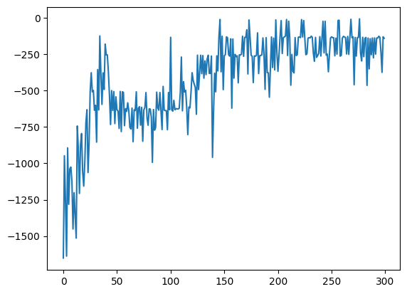

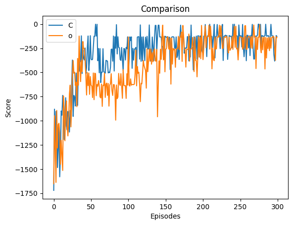

```python
perAgent, perdqn_score = train_model_eps(PERDoubleDQNAgent,300)
plot_tuples([(ddqn_score,"base"),(perdqn_score,"action")],"Compare Dueling DQN")
```

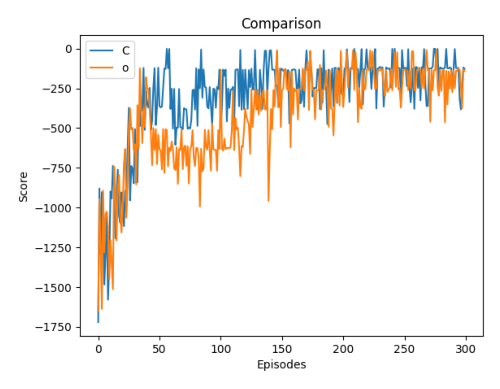

```python
torch.save(perAgent.policy_net.state_dict(), "./rl_models/per_dqn.pt")
showImage("./Imgs_RL/per_ddqn.png")
```

Observations:

**Training Time**

- Prioritised Replay is significant slower in terms of training as it add more model complexity
- The time take for 300 episodes was around 1.5 times longer

**Performance**

- As seen on the graph PER did not provide any groundbreaking results
- It took longer to converge
- At the end had similiar performacne to a Double DQN

#### Limitations of PER in the Pendulum Problem

In the case of the Pendulum problem, certain characteristics of the environment might limit the effectiveness of Prioritized Replay:

1. Lack of Sparse Rewards

The Pendulum environment typically provides continuous and non-sparse rewards. Since Prioritized Replay is particularly beneficial in problems with sparse and informative rewards, its application in the Pendulum problem may not yield significant improvements.

2. Continuous Action Space

The Pendulum problem involves a continuous action space, making it inherently different from discrete action space problems where prioritized replay has shown more impact. The continuous nature of actions might reduce the influence of prioritization on learning.

3. Lack of Temporal Dependencies

In some environments, prioritized replay helps to address temporal dependencies in the data, ensuring that crucial experiences are replayed and learned more frequently. In the Pendulum problem, where the state transitions are less dependent on past experiences, prioritized replay may not provide a substantial advantage.

4. Lack of Environmental Complexity

The pendulum environment is relatively simple compared to other like Atari games or snakes and ladders. In those environments, sampling the right info is more important and thus, PER might be more successful.

#### Noisy Networks

Noisy Networks introduce stochasticity directly into the parameters of a neural network, allowing the model to explore action spaces more effectively.

##### Key Benefits:

1. **Exploration Enhancement:**
   - Traditional exploration strategies, such as epsilon-greedy, might not be sufficient in complex environments. Noisy Networks introduce random perturbations into the network's weights, allowing the agent to explore a broader range of actions.
2. **Parametric Noise:**
   - Noisy Layers model exploration as parameterized noise added to the activations of the layer. This noise is adaptive and trainable, providing the network with the flexibility to learn the level of exploration required for optimal performance.
3. **Reducing Overestimation Bias:**
   - Noisy Networks can help mitigate overestimation bias, a common challenge in DDQN. By introducing stochasticity during action selection, the agent becomes less reliant on deterministic Q-values, resulting in a more accurate estimation of state-action values.

##### Implementation in DDQN:

To integrate Noisy Networks into our DDQN implementation, we can just include Noisy Layers to the fully connected layers of both the policy and target networks. This can be achieved using PyTorch's NoisyLinear layers.

```python
class DDQN_MLP_Noisy(nn.Module):
    def __init__(self, inp, out, lr):
        super(DDQN_MLP_Noisy, self).__init__()

        self.layer1 = nn.Linear(inp, 32)
        self.layer2 = nn.Linear(32, 64)

        self.value_stream = nn.Sequential(
            nn.Linear(64, 64),
            nn.LeakyReLU(inplace=True),
            NoisyLinear(64, 1)
        )

        self.advantage_stream = nn.Sequential(
            nn.Linear(64, 64),
            nn.LeakyReLU(inplace=True),
            NoisyLinear(64, out)
        )

        self.lr = lr
        self.optimizer = optim.Adam(self.parameters(), lr=self.lr)

    def forward(self, x):
        x = self.layer1(x)
        x = F.leaky_relu(x)
        x = self.layer2(x)
        x = F.leaky_relu(x)

        values = self.value_stream(x)
        advantages = self.advantage_stream(x)
        q_values = values + advantages - advantages.mean()

        return q_values
```

```python
class NoisyDoubleDQNAgent:
    def __init__(self):
        self.steps = 0
        self.memory = Memory(10000)

        # Greedy Episilon Hyperparams
        self.epsilon       = 1.0
        self.epsilon_decay = 0.98
        self.epsilon_min   = 0.001

        self.batch_size = 256
        self.adamlr = 0.001
        self.targetlr = 0.01
        self.gamma = 0.98

        self.numOfAction = 20
        self.action_array = np.concatenate(((-1 *( np.exp(np.linspace(0, 1.09, 10)) - 1))[::-1], np.exp(np.linspace(0, 1.09, 10)) - 1)).tolist()

        self.policy_net = DDQN_MLP_Noisy(3, self.numOfAction,self.adamlr)
        self.target_net = DDQN_MLP_Noisy(3, self.numOfAction,self.adamlr)
        self.target_net.load_state_dict(self.policy_net.state_dict())

    def transform_choice(self, num):
        return self.action_array[int(num)]

    def action(self,state):

        sample = np.random.rand()

        if sample > self.epsilon:
            with torch.no_grad():
                choice = float(torch.argmax(self.policy_net(state)).numpy())
                action = self.transform_choice(choice)
        else:
            choice = np.random.choice([n for n in range(self.numOfAction)])
            action = self.transform_choice(choice)

        return choice, action

    def optimize(self):
        if len(self.memory) < self.batch_size:
            return

        batch = self.memory.sample(self.batch_size)
        state, action, reward, next_state = batch
        action = action.type(torch.int64)

        with torch.no_grad():
            expected_q = self.target_net(next_state).max(1)[0].unsqueeze(1)
            expected = reward + self.gamma * expected_q

        # Actual values - Policy Net
        actual = self.policy_net(state).gather(1,action)

        # Back_propagation
        loss = F.smooth_l1_loss(actual, expected)
        self.policy_net.optimizer.zero_grad()
        loss.mean().backward()
        nn.utils.clip_grad_norm_(self.policy_net.parameters(), 0.5)
        self.policy_net.optimizer.step()

        for target_param,param in zip(self.target_net.parameters(),self.policy_net.parameters()):
            target_param.data.copy_(target_param.data * (1.0 - self.targetlr) + param.data * self.targetlr)
```

```
Episode: 0, Score: -985.0381655892998, Threshold: 1.0
Episode: 1, Score: -1714.2130167318405, Threshold: 0.98
Episode: 2, Score: -1181.034698308323, Threshold: 0.9603999999999999
Episode: 3, Score: -1312.6121774962191, Threshold: 0.9411919999999999
Episode: 4, Score: -1164.8999911553904, Threshold: 0.9223681599999999
Episode: 5, Score: -959.0617069234175, Threshold: 0.9039207967999998
Episode: 6, Score: -1527.6393912435121, Threshold: 0.8858423808639998
Episode: 7, Score: -1320.233344275734, Threshold: 0.8681255332467198
Episode: 8, Score: -1176.9695636244257, Threshold: 0.8507630225817854
Episode: 9, Score: -1342.8412274654556, Threshold: 0.8337477621301497
Episode: 10, Score: -986.960926892078, Threshold: 0.8170728068875467
Episode: 11, Score: -1062.4448026404207, Threshold: 0.8007313507497957
Episode: 12, Score: -972.3207580584801, Threshold: 0.7847167237347998
Episode: 13, Score: -902.5422976890397, Threshold: 0.7690223892601038
Episode: 14, Score: -1177.3752235010872, Threshold: 0.7536419414749017
Episode: 15, Score: -1024.3545401697556, Threshold: 0.7385691026454037
Episode: 16, Score: -774.7204592429432, Threshold: 0.7237977205924956
Episode: 17, Score: -757.1400016347809, Threshold: 0.7093217661806457
Episode: 18, Score: -1315.8327585101079, Threshold: 0.6951353308570327
Episode: 19, Score: -745.6832131073966, Threshold: 0.6812326242398921
Episode: 20, Score: -735.7144237728293, Threshold: 0.6676079717550942
Episode: 21, Score: -1034.7173241163061, Threshold: 0.6542558123199923
Episode: 22, Score: -502.4447797195432, Threshold: 0.6411706960735924
Episode: 23, Score: -495.0951185756293, Threshold: 0.6283472821521205
Episode: 24, Score: -607.6075211399731, Threshold: 0.6157803365090782
Episode: 25, Score: -375.6448036480414, Threshold: 0.6034647297788965
Episode: 26, Score: -611.3372514124007, Threshold: 0.5913954351833186
Episode: 27, Score: -624.5773879331938, Threshold: 0.5795675264796523
Episode: 28, Score: -602.5785525496148, Threshold: 0.5679761759500592
Episode: 29, Score: -851.4583977552861, Threshold: 0.5566166524310581
Episode: 30, Score: -500.4302282047774, Threshold: 0.5454843193824369
Episode: 31, Score: -503.57280895897645, Threshold: 0.5345746329947881
Episode: 32, Score: -380.48299983942684, Threshold: 0.5238831403348924
Episode: 33, Score: -518.8670051936493, Threshold: 0.5134054775281945
Episode: 34, Score: -255.55444685317934, Threshold: 0.5031373679776306
Episode: 35, Score: -742.9890228785888, Threshold: 0.493074620618078
Episode: 36, Score: -502.83821203857804, Threshold: 0.48321312820571644
Episode: 37, Score: -807.6301453750666, Threshold: 0.4735488656416021
Episode: 38, Score: -382.6656676284146, Threshold: 0.46407788832877006
Episode: 39, Score: -698.781811298458, Threshold: 0.45479633056219465
```

[output cut: 245 more lines]

```
Episode: 285, Score: -409.68785767409867, Threshold: 0.003158141411002513
Episode: 286, Score: -6.677609916190963, Threshold: 0.003094978582782463
Episode: 287, Score: -129.43425538056582, Threshold: 0.0030330790111268136
Episode: 288, Score: -393.49557632580445, Threshold: 0.0029724174309042773
Episode: 289, Score: -129.7123348891668, Threshold: 0.002912969082286192
Episode: 290, Score: -8.27240859711189, Threshold: 0.002854709700640468
Episode: 291, Score: -129.65113839276734, Threshold: 0.0027976155066276585
Episode: 292, Score: -124.45517231619542, Threshold: 0.0027416631964951054
Episode: 293, Score: -243.70429649057212, Threshold: 0.0026868299325652034
Episode: 294, Score: -248.01233794097854, Threshold: 0.002633093333913899
Episode: 295, Score: -130.82128490122454, Threshold: 0.002580431467235621
Episode: 296, Score: -6.611867468555783, Threshold: 0.0025288228378909086
Episode: 297, Score: -122.2240873267804, Threshold: 0.0024782463811330903
Episode: 298, Score: -131.0894097374712, Threshold: 0.0024286814535104282
Episode: 299, Score: -130.62957733405153, Threshold: 0.0023801078244402194
```

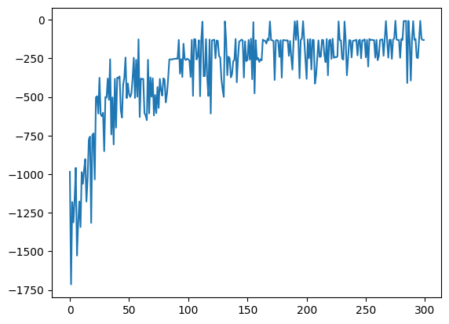

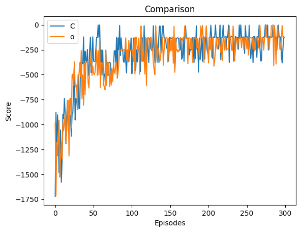

```python
noisyAgent, noisydqn_score = train_model_eps(NoisyDoubleDQNAgent,300)
plot_tuples([(ddqn_score,"base"),(noisydqn_score,"noisy")],"Compare Dueling DQN")
```

```python
evaluate_model(noisyAgent,100)
```

```
Evaluating Episode: 1, Score: -242.36706002028535
Evaluating Episode: 2, Score: -121.79841189782114
Evaluating Episode: 3, Score: -240.41279461565233
Evaluating Episode: 4, Score: -127.72978182811494
Evaluating Episode: 5, Score: -119.73980952027595
Evaluating Episode: 6, Score: -242.78489675971537
Evaluating Episode: 7, Score: -130.37836736195524
Evaluating Episode: 8, Score: -122.83704554803361
Evaluating Episode: 9, Score: -128.80260110947822
Evaluating Episode: 10, Score: -128.36572473552474
Evaluating Episode: 11, Score: -124.46357355136362
Evaluating Episode: 12, Score: -128.7123786678771
Evaluating Episode: 13, Score: -119.15434516381136
Evaluating Episode: 14, Score: -118.20710338527971
Evaluating Episode: 15, Score: -122.9499804636446
Evaluating Episode: 16, Score: -132.32282399257068
Evaluating Episode: 17, Score: -252.3042969684047
Evaluating Episode: 18, Score: -242.06014793845304
Evaluating Episode: 19, Score: -129.29443947002994
Evaluating Episode: 20, Score: -126.67383153181504
Evaluating Episode: 21, Score: -124.05232938443659
Evaluating Episode: 22, Score: -240.48163891609556
Evaluating Episode: 23, Score: -127.22346126487619
Evaluating Episode: 24, Score: -123.41607989130762
Evaluating Episode: 25, Score: -241.04745354948452
Evaluating Episode: 26, Score: -235.33530177332167
Evaluating Episode: 27, Score: -130.77644910114887
Evaluating Episode: 28, Score: -117.91884420334218
Evaluating Episode: 29, Score: -261.7378941436827
Evaluating Episode: 30, Score: -10.65900671704475
Evaluating Episode: 31, Score: -4.7690105203104745
Evaluating Episode: 32, Score: -123.5923315608618
Evaluating Episode: 33, Score: -128.79522410512146
Evaluating Episode: 34, Score: -317.12173366472246
Evaluating Episode: 35, Score: -122.53587416817477
Evaluating Episode: 36, Score: -120.87126719761699
Evaluating Episode: 37, Score: -123.50109332008114
Evaluating Episode: 38, Score: -317.97586109478016
Evaluating Episode: 39, Score: -129.95508612756615
Evaluating Episode: 40, Score: -129.01812424541527
```

[output cut: 46 more lines]

```
Evaluating Episode: 87, Score: -5.645634904386682
Evaluating Episode: 88, Score: -127.33127872752965
Evaluating Episode: 89, Score: -251.48364187553528
Evaluating Episode: 90, Score: -127.16749733798642
Evaluating Episode: 91, Score: -124.28845399144106
Evaluating Episode: 92, Score: -117.79334576643163
Evaluating Episode: 93, Score: -126.62748419583745
Evaluating Episode: 94, Score: -119.08132905322512
Evaluating Episode: 95, Score: -229.93901043990434
Evaluating Episode: 96, Score: -247.07964971131943
Evaluating Episode: 97, Score: -125.34302478988977
Evaluating Episode: 98, Score: -5.384091622532529
Evaluating Episode: 99, Score: -122.1778794820597
Evaluating Episode: 100, Score: -4.730923944923084
Final Score: -149.9369829998853
```

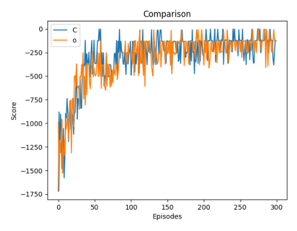

```python
torch.save(noisyAgent.policy_net.state_dict(), "./rl_models/noisy_dqn.pt")
showImage("./Imgs_RL/noisy_ddqn.png")
```

Observations:

**Performance**

- Noisy Netowrk performs slightly better than DDQN with a score of -149
- Training stability is around the same

**Training Time**

- Surprisingly Noisy DQN didn't take that long to converge.

Overall, I think that adding the Noisy layer was beneficial as it allowed the model to explore the action space more and give better results.

## Evaluation of Final Model

```
Episode: 0, Score: -1693.35497018581, Threshold: 1.0
Episode: 1, Score: -1044.7013616337586, Threshold: 0.98
Episode: 2, Score: -1187.431187324627, Threshold: 0.9603999999999999
Episode: 3, Score: -1166.7596586114566, Threshold: 0.9411919999999999
Episode: 4, Score: -1663.1783036962433, Threshold: 0.9223681599999999
Episode: 5, Score: -950.4959029965835, Threshold: 0.9039207967999998
Episode: 6, Score: -1680.7975025479834, Threshold: 0.8858423808639998
Episode: 7, Score: -1100.980675995632, Threshold: 0.8681255332467198
Episode: 8, Score: -1671.1550797556934, Threshold: 0.8507630225817854
Episode: 9, Score: -974.6130274564158, Threshold: 0.8337477621301497
Episode: 10, Score: -1305.3232484995503, Threshold: 0.8170728068875467
Episode: 11, Score: -1072.0908032056427, Threshold: 0.8007313507497957
Episode: 12, Score: -1361.8069988969464, Threshold: 0.7847167237347998
Episode: 13, Score: -851.9698150368514, Threshold: 0.7690223892601038
Episode: 14, Score: -1054.3927685195354, Threshold: 0.7536419414749017
Episode: 15, Score: -1137.1286073679205, Threshold: 0.7385691026454037
Episode: 16, Score: -1073.3082234401422, Threshold: 0.7237977205924956
Episode: 17, Score: -985.8390572699592, Threshold: 0.7093217661806457
Episode: 18, Score: -1021.3770201572906, Threshold: 0.6951353308570327
Episode: 19, Score: -1088.295966057418, Threshold: 0.6812326242398921
Episode: 20, Score: -756.2332162718371, Threshold: 0.6676079717550942
Episode: 21, Score: -1017.8896736621604, Threshold: 0.6542558123199923
Episode: 22, Score: -622.0508260226603, Threshold: 0.6411706960735924
Episode: 23, Score: -839.5403833586398, Threshold: 0.6283472821521205
Episode: 24, Score: -492.9209812680174, Threshold: 0.6157803365090782
Episode: 25, Score: -994.757082294239, Threshold: 0.6034647297788965
Episode: 26, Score: -254.9218431438629, Threshold: 0.5913954351833186
Episode: 27, Score: -1031.5130283281892, Threshold: 0.5795675264796523
Episode: 28, Score: -251.4691637480608, Threshold: 0.5679761759500592
Episode: 29, Score: -622.0983251268722, Threshold: 0.5566166524310581
Episode: 30, Score: -751.2666401102085, Threshold: 0.5454843193824369
Episode: 31, Score: -250.4063085808503, Threshold: 0.5345746329947881
Episode: 32, Score: -612.0949838580285, Threshold: 0.5238831403348924
Episode: 33, Score: -379.42926431560574, Threshold: 0.5134054775281945
Episode: 34, Score: -632.2597086739788, Threshold: 0.5031373679776306
Episode: 35, Score: -318.95241355105117, Threshold: 0.493074620618078
Episode: 36, Score: -253.9471485833062, Threshold: 0.48321312820571644
Episode: 37, Score: -252.91026011903278, Threshold: 0.4735488656416021
Episode: 38, Score: -495.81405681147305, Threshold: 0.46407788832877006
Episode: 39, Score: -253.7527949385262, Threshold: 0.45479633056219465
```

[output cut: 445 more lines]

```
Episode: 485, Score: -243.4384642651033, Threshold: 0.0009984306091742447
Episode: 486, Score: -122.93125814709515, Threshold: 0.0009984306091742447
Episode: 487, Score: -127.04404331178853, Threshold: 0.0009984306091742447
Episode: 488, Score: -126.06794128560537, Threshold: 0.0009984306091742447
Episode: 489, Score: -125.23594536678952, Threshold: 0.0009984306091742447
Episode: 490, Score: -121.57453819299468, Threshold: 0.0009984306091742447
Episode: 491, Score: -338.93014292828866, Threshold: 0.0009984306091742447
Episode: 492, Score: -4.897988097437928, Threshold: 0.0009984306091742447
Episode: 493, Score: -2.995838769657938, Threshold: 0.0009984306091742447
Episode: 494, Score: -230.94928285646242, Threshold: 0.0009984306091742447
Episode: 495, Score: -131.40632479262743, Threshold: 0.0009984306091742447
Episode: 496, Score: -3.769789911865733, Threshold: 0.0009984306091742447
Episode: 497, Score: -289.50799208843245, Threshold: 0.0009984306091742447
Episode: 498, Score: -236.8091230970299, Threshold: 0.0009984306091742447
Episode: 499, Score: -221.02126227731958, Threshold: 0.0009984306091742447
```

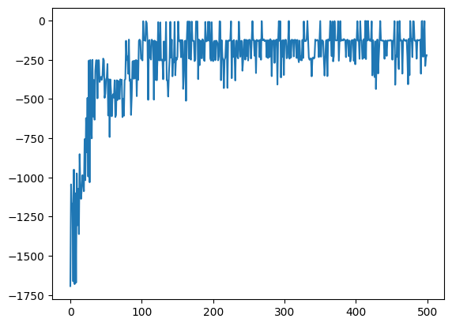

```python
finalAgent, final_score = train_model_eps(NoisyDoubleDQNAgent,500)
```

```python
evaluate_model(finalAgent,100)
```

```
Evaluating Episode: 1, Score: -130.8485724129405
Evaluating Episode: 2, Score: -8.086043676251842
Evaluating Episode: 3, Score: -132.91841628529534
Evaluating Episode: 4, Score: -132.20083976079079
Evaluating Episode: 5, Score: -128.09963226528143
Evaluating Episode: 6, Score: -231.66940733682839
Evaluating Episode: 7, Score: -133.37162811611785
Evaluating Episode: 8, Score: -132.00232955688094
Evaluating Episode: 9, Score: -231.6252922993193
Evaluating Episode: 10, Score: -242.14166728843674
Evaluating Episode: 11, Score: -8.329883901581784
Evaluating Episode: 12, Score: -127.10209625071896
Evaluating Episode: 13, Score: -129.31930826405573
Evaluating Episode: 14, Score: -130.93186152162636
Evaluating Episode: 15, Score: -121.42012281408948
Evaluating Episode: 16, Score: -130.70775486074578
Evaluating Episode: 17, Score: -129.08057334219853
Evaluating Episode: 18, Score: -8.51425919396035
Evaluating Episode: 19, Score: -7.912727216808989
Evaluating Episode: 20, Score: -238.5153605750016
Evaluating Episode: 21, Score: -254.22943024904586
Evaluating Episode: 22, Score: -233.96251605130624
Evaluating Episode: 23, Score: -126.47797443962172
Evaluating Episode: 24, Score: -231.8426027293189
Evaluating Episode: 25, Score: -134.80069298316826
Evaluating Episode: 26, Score: -129.88966242934544
Evaluating Episode: 27, Score: -122.86602325358098
Evaluating Episode: 28, Score: -234.55027936179818
Evaluating Episode: 29, Score: -134.50084694036167
Evaluating Episode: 30, Score: -125.29161619235558
Evaluating Episode: 31, Score: -133.60993118770367
Evaluating Episode: 32, Score: -238.67417686228185
Evaluating Episode: 33, Score: -8.580048872177867
Evaluating Episode: 34, Score: -129.7800790119593
Evaluating Episode: 35, Score: -124.75675512756538
Evaluating Episode: 36, Score: -126.66294535460698
Evaluating Episode: 37, Score: -133.2964376286925
Evaluating Episode: 38, Score: -133.19707482596914
Evaluating Episode: 39, Score: -131.31048183478194
Evaluating Episode: 40, Score: -244.07721665022194
```

[output cut: 46 more lines]

```
Evaluating Episode: 87, Score: -132.10121313023345
Evaluating Episode: 88, Score: -125.73492420007791
Evaluating Episode: 89, Score: -233.4007877893496
Evaluating Episode: 90, Score: -122.19944634310747
Evaluating Episode: 91, Score: -127.47998539835308
Evaluating Episode: 92, Score: -126.95203254299423
Evaluating Episode: 93, Score: -126.95260319151612
Evaluating Episode: 94, Score: -8.195556496887534
Evaluating Episode: 95, Score: -7.915958621786024
Evaluating Episode: 96, Score: -1850.0886253806118
Evaluating Episode: 97, Score: -9.975444311075977
Evaluating Episode: 98, Score: -238.5089947878025
Evaluating Episode: 99, Score: -131.17847069903485
Evaluating Episode: 100, Score: -124.77295283743057
Final Score: -170.01447251911344
```

```python
visualize_model(finalAgent,3)
```

```
Visualizing Episode: 1, Score: -126.29451481752481
Visualizing Episode: 2, Score: -246.16612591783476
Visualizing Episode: 3, Score: -270.686294221618
```

## Conclusion

In conclusion, we have learnt how to use DQN to create a Reinforcement Learning algorithm that can balance a pendulum. At the start it was really frustrating as the simple DQN kept giving inconsistent results. But as we applied improvements both to stabilisation and architecture, we saw substantial improvement in the model.

An essential takeaway from this experience is the understanding that the simplicity of the pendulum problem limits the effectiveness of advanced methods like dueling and prioritized experience replay (PER). In cases where the environment itself is straightforward, the additional complexity introduced by these methods may not yield substantial benefits. Thus, the choice of reinforcement learning techniques should align with the complexity of the problem at hand to strike an optimal balance between simplicity and effectiveness.